# STA552 Project #3 CART, Bagging and Random Forest

Junjie (Jason) Mei

05/07/2025

# 1 Introduction

This Telco Customer Churn dataset is the data from focused customer retention programs in a company called as Telco. This dataset can be used to predict behavior to retain customers. We can analyze all relevant customer data and develop focused customer retention programs. Each row represents a customer, each column contains customer’s attributes. The dataset includes information about: 1. Customers who left within the last month – the column is called Churn; 2. Services that each customer has signed up for – phone, multiple lines, internet, online security, online backup, device protection, tech support, and streaming TV and movies; 3. Customer account information – how long they’ve been a customer, contract, payment method, paperless billing, monthly charges, and total charges; 4.Demographic info about customers – gender, and if they have partners and dependents.

The total sample size is 7043 rows (customers). There are 21 variables, including 3 numerical variables and other categorical variables:

- customerID
- gender: Whether the customer is a male or a female
- SeniorCitizen: Whether the customer is a senior citizen or not (1, 0)
- Partner: Whether the customer has a partner or not (Yes, No)
- Dependents: Whether the customer has a partner or not (Yes, No)
- tenure: Number of months the customer has stayed with the company
- PhoneService: Whether the customer has a phone service or not (Yes, No)
- MultipleLines: Whether the customer has multiple lines or not (Yes, No, No phone service)
- InternetService: Customer’s internet service provider (DSL, Fiber optic, No)
- OnlineSecurity: Whether the customer has online security or not (Yes, No, No internet service)
- OnlineBackup: Whether the customer has online backup or not (Yes, No, No internet service)
- DeviceProtection: Whether the customer has device protection or not (Yes, No, No internet service)
- TechSupport: Whether the customer has tech support or not (Yes, No, No internet service)
- StreamingTV: Whether the customer has streaming TV or not (Yes, No, No internet service)
- StreamingMovies: Whether the customer has streaming movies or not (Yes, No, No internet service)
- categorical values: The contract term of the customer (Month-to-month, One year, Two year)
- PaperlessBilling: Whether the customer has paperless billing or not (Yes, No)
- PaymentMethod: The customer’s payment method (Electronic check, Mailed check, Bank transfer (automatic), Credit card (automatic))
- MonthlyCharges: The amount charged to the customer monthly
- TotalCharges: The total amount charged to the customer
- Churn: Whether the customer churned or not (Yes or No)

Among these variables, only TotalCharges variable has 11 missing values, and all other variables have no missing values at all.

# 2 Data Preparation

## 2.1 Exploratory Data Analysis (EDA), Feature Engineering and Imputation

We use this dataset to generate linear and non-linear regression models to predict customers’ behavior to retain in this programs, and the numerical variable TotalCharges. To generate these models, first of all, we convert all categorical variables into dummy variables (only 0 and 1 values). For MultipleLines, OnlineSecurity, OnlineBackup, DeviceProtection, TechSupport, StreamingTV, StreamingMovies variables, “Yes” is converted to 1, “No” and “No phone service” or “No internet service” are converted to 0. Churn, PaperlessBilling, PhoneServices, Partner, Dependents (Yes or No) are all converted to dummy variables (0 and 1 values). gender’s Male is converted to 1, and female is 0. InternetServices (3 categorical values), PaymentMethod (4 categorical values) and Contract (3 categorical values) are converted to 3 (InternetServiceNo, InternetServiceDSL and InternetServiceFiberOptic),4 (PaymentMethodECheck, PaymentMethodMCheck, PaymentMethodCreditCard, PaymentMethodBankTranfer),and 3 (ContractMonth, Contract1Year, Contract2Year) dummy variables (only 0 and 1 values) respectively.

For 3 numerical variables, first of all, we compared the three numerical variables’ distribution and their mutual relationship with their Pairwise scatter Plots.

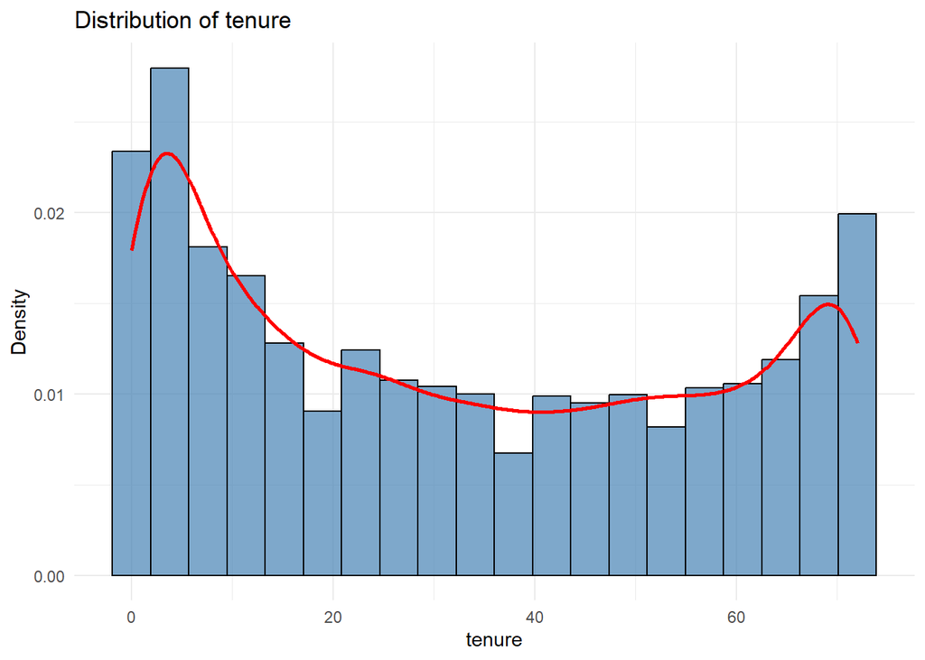

```r
# load Telco Customer Churn data
# setwd("C:/Users/Junjie Mei/Desktop/WCU/2025Spring/STA552/Week2")
churn <- read.csv("https://jm1006958.github.io/STA552/WA_Fn-UseC_-Telco-Customer-Churn.csv")

# Convert "Yes" to 1 and "No" to 0
churn$Partner1 <- ifelse(churn$Partner == "Yes", 1, 0)
churn$Dependents1 <- ifelse(churn$Dependents == "Yes", 1, 0)
churn$PhoneService1 <- ifelse(churn$PhoneService == "Yes", 1, 0)
churn$MultipleLines1 <- ifelse(churn$MultipleLines == "Yes", 1, 0)
churn$InternetService1 <- ifelse(churn$InternetService == "No", 0, 1)
churn$OnlineSecurity1 <- ifelse(churn$OnlineSecurity == "Yes", 1, 0)
churn$OnlineBackup1 <- ifelse(churn$OnlineBackup == "Yes", 1, 0)
churn$DeviceProtection1 <- ifelse(churn$DeviceProtection == "Yes", 1, 0)
churn$TechSupport1 <- ifelse(churn$TechSupport == "Yes", 1, 0)
churn$StreamingTV1 <- ifelse(churn$StreamingTV == "Yes", 1, 0)
churn$StreamingMovies1 <- ifelse(churn$StreamingMovies == "Yes", 1, 0)
churn$PaperlessBilling1 <- ifelse(churn$PaperlessBilling == "Yes", 1, 0)
churn$Churn1 <- ifelse(churn$Churn == "Yes", 1, 0)
churn$InternetServiceNo <- ifelse(churn$InternetService == "No", 1, 0)
churn$InternetServiceDSL <- ifelse(churn$InternetService == "DSL", 1, 0)
churn$InternetServiceFiberOptic <- ifelse(churn$InternetService == "Fiber optic", 1, 0)
churn$ContractMonth <- ifelse(churn$Contract == "Month-to-month", 1, 0)
churn$Contract1Year <- ifelse(churn$Contract == "One year", 1, 0)
churn$Contract2Year <- ifelse(churn$Contract == "Two year", 1, 0)
churn$PaymentMethodECheck <- ifelse(churn$PaymentMethod == "Electronic check", 1, 0)
churn$PaymentMethodMCheck <- ifelse(churn$PaymentMethod == "Mailed check", 1, 0)
churn$PaymentMethodCreditCard <- ifelse(churn$PaymentMethod == "Credit card (automatic)", 1, 0)
churn$PaymentMethodBankTranfer <- ifelse(churn$PaymentMethod == "Bank transfer (automatic)", 1, 0)
churn$Churn1 <- ifelse(churn$Churn == "Yes", 1, 0)
churn$gender1 <- ifelse(churn$gender == "Male", 1, 0)


library(tidyverse)
library(pander)

par(mfrow = c(1,2))

ggplot(churn, aes(x = tenure)) +
  geom_histogram(aes(y = ..density..), bins = 20, fill = "steelblue", color = "black", alpha = 0.7) +
  geom_density(color = "red", size = 1) +  # Overlay density plot
  ggtitle("Distribution of tenure") +
  xlab("tenure") +
  ylab("Density") +
  theme_minimal();
```

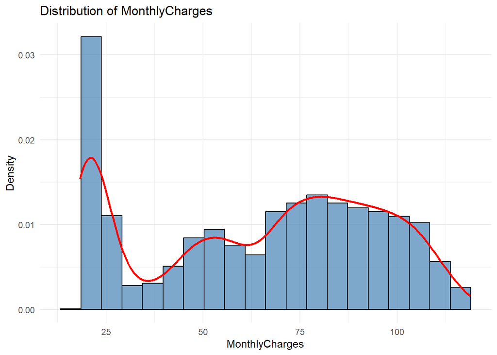

```r
ggplot(churn, aes(x = MonthlyCharges)) +
  geom_histogram(aes(y = ..density..), bins = 20, fill = "steelblue", color = "black", alpha = 0.7) +
  geom_density(color = "red", size = 1) +  # Overlay density plot
  ggtitle("Distribution of MonthlyCharges") +
  xlab("MonthlyCharges") +
  ylab("Density") +
  theme_minimal();
```

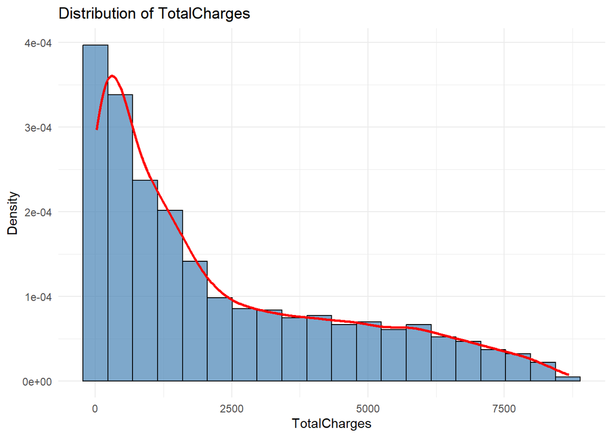

```r
ggplot(churn, aes(x = TotalCharges)) +
  geom_histogram(aes(y = ..density..), bins = 20, fill = "steelblue", color = "black", alpha = 0.7) +
  geom_density(color = "red", size = 1) +  # Overlay density plot
  ggtitle("Distribution of TotalCharges") +
  xlab("TotalCharges") +
  ylab("Density") +
  theme_minimal();
```

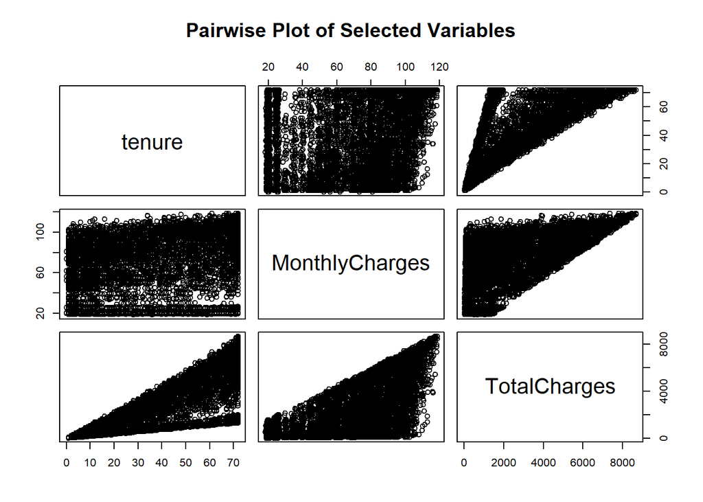

```r
#print(churn)
pairs(churn[, c("tenure", "MonthlyCharges", "TotalCharges")], main = "Pairwise Plot of Selected Variables")
```

Since the TotalCharges variable has 11 missing values, for imputation purposes, we are trying to find some association of TotalCharges with tenure and MonthlyCharges. From the above Pairwise Plots of these 3 numerical variables and that tenure is the Number of months the customer has stayed with the company, we created a new feature variable Prd_TotalCharges = tenure*MonthlyCharges, and re-do the pairwise plots of these numerical variables, and found that just as predicted, the Prd_TotalCharges variable is strongly and positively correlated with the TotalCharges variable. Therefore we used the Regression-based Imputation approach to imputate the 11 missing values in TotalCharges shown as below.

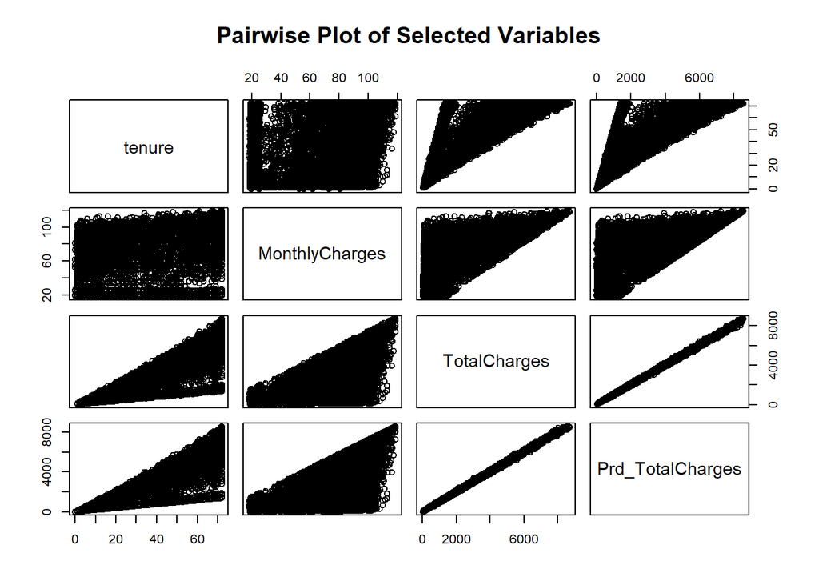

```r
churn2 <- churn[, c("tenure", "MonthlyCharges", "TotalCharges", "Partner1", "Dependents1", "PhoneService1", "MultipleLines1", "InternetService1", "OnlineSecurity1", "SeniorCitizen",
                    "OnlineBackup1", "DeviceProtection1", "TechSupport1",
                    "StreamingTV1", "StreamingMovies1", "PaperlessBilling1",  "InternetServiceNo", "InternetServiceFiberOptic",
                    "InternetServiceDSL", "ContractMonth",
                    "Contract1Year", "Contract2Year", "PaymentMethodECheck",
                    "PaymentMethodMCheck", "PaymentMethodCreditCard", "PaymentMethodBankTranfer",
                    "gender1", "Churn"   )]

#churn2$log_TotalCharges <- log(churn2$TotalCharges)
churn2$Prd_TotalCharges <- churn2$MonthlyCharges*churn2$tenure
#churn2$Prd_TotalCharges <- NULL
pairs(churn2[, c("tenure", "MonthlyCharges", "TotalCharges", "Prd_TotalCharges")], main = "Pairwise Plot of Selected Variables")
```

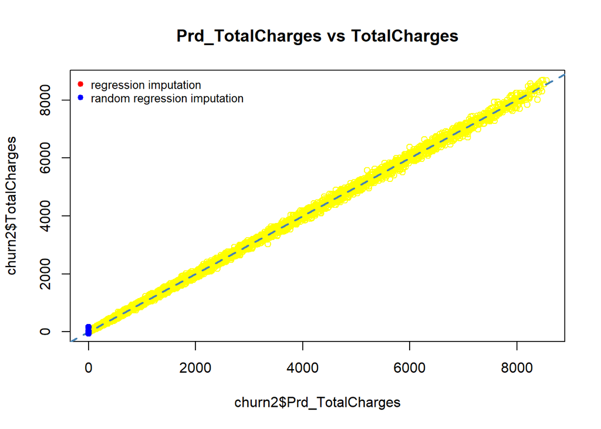

```r
#  Regression-based Imputation for Numerical Features

pred.totalcharges = lm(TotalCharges ~ Prd_TotalCharges, data = churn2)
newdata = churn2[is.na(churn2$TotalCharges),]
pred.TotalCharges = predict(pred.totalcharges, newdata = newdata)
m0 = sum(is.na(churn2$TotalCharges))
pred.resid = resid(pred.totalcharges)
pred.yrand = pred.TotalCharges + sample(pred.resid, m0, replace = TRUE)

# Ensure no missing values in x-axis data
#complete_cases <- !is.na(churn2$Prd_TotalCharges) & !is.na(churn2$TotalCharges)
plot(churn2$Prd_TotalCharges, churn2$TotalCharges, main = "Prd_TotalCharges vs TotalCharges",col="yellow")

abline(pred.totalcharges, col = "steelblue", lty = 2, lwd = 2)

# Plot only for missing values
if (m0 > 0) {
  points(newdata$Prd_TotalCharges, pred.TotalCharges, pch=19, col = "red")
  points(newdata$Prd_TotalCharges, pred.yrand, pch=19, col = "blue")
}

legend("topleft", c("regression imputation", "random regression imputation"),
       col=c("red", "blue"), pch=rep(19,2), bty="n", cex = 0.8)
```

```r
churn2$TotalCharges[is.na(churn2$TotalCharges)] <- pred.yrand
```

From the Pairwise plot of TotalCharges and the feature variable Prd_TotalCharges, we could see the TotalCharges is perfectly in positively linear relationship with the interaction of tenure*MonthlyCharges, Prd_TotalCharges. In Project 2, we tested different linear and non-linear regression models in predicting TotalCharges with and without this feature variable Prd_TotalCharges. Without this Prd_TotalCharges, the linear models performs really bad, while RBF SVM, a non-linear regression model performs much better than several linear regression models.

Here in this project, we will use Classification and Regression Trees (CART) Regression and Classification methods, and two ensemble methods—bagging and random forests, to predict TotalCharges with two numerical variables tenure and MonthlyCharges without the Prd_TotalCharges feature variables, and predict the dichotomous variable churn.

# 3 Part I: Predict TotalCharges with CART Regression, Bagging Regression and Random Forest Regression

Based on the the analysis above in Project #2, in this project we use the performance metrics of traditional linear regression with stepwise selection (AIC) - LSE.Reg with the feature variable Prd_TotalCharges as the best reference (RMSE 68.8; MSE 4354; MAE 44.75), to evaluate the performance of CART regression, Bagging regression and Random Forest regression to predict TotalCharges with the predictor variable tenure and MonthlyCharges.

## 3.1 CART Regression

The Classification and Regression Trees (CART) algorithm is an intuitive but powerful machine learning algorithm that can be used to perform both regression and classification. It is also the base algorithm used to define several other ensemble machine learning algorithms.

For CART regression, Regression Trees are used for predicting continuous outcomes. The splits are chosen to minimize the variance or MSE of the target variable within each subset.The basic logical process of in CART regression tree implementation includes the following steps:

- *Tree Induction*
  - Start with the entire dataset at the root node
  - Recursively partition the data into subsets
  - Create child nodes for each partition
- *Splitting Criteria*
  - Feature selection: Evaluate all possible features for splitting
  - Splitting point: For continuous features, find the optimal value to split
  - Common criteria:
    - Minimize sum of squared errors (SSE)
    - Reduction in variance
- *Stopping Rule* - Stop recursion when:
  - Node contains fewer than the minimum number of observations
  - Depth reaches maximum limit
  - Improvement in model fit is below the threshold
  - All observations in the node have the same target value
- *Pruning Process*
  - Grow an overly complex tree first
  - Use cost-complexity pruning to avoid overfitting
  - Select optimal subtree using cross-validation
- *Prediction*
  - Traverse tree with new observation
  - Reach terminal node (leaf)
  - Use mean value of training observations **in that node** as prediction

Next, we follows the above suggested logical steps to build a regressions. The initinal regression tree is shown below:

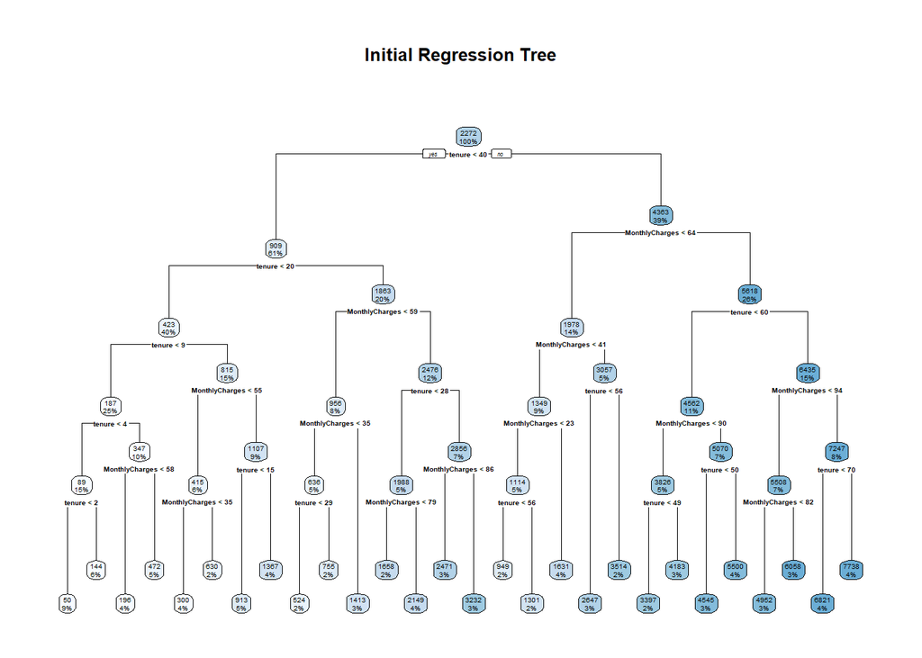

```r
# Load required packages and data
library(rpart)          # For regression trees
library(rpart.plot)     # For visualizing trees
library(MASS)           # Contains churn_lin dataset
# Load the numerical dataset
churn_lin <- churn2[,c("tenure", "MonthlyCharges", "TotalCharges")]
#X <- as.matrix(churn_lin[, -3])  # Features (all columns except the target)
#y <- churn_lin$TotalCharges  # Target variable (TotalCharges)

# Set seed for reproducibility
set.seed(123)

# Split data into training (70%) and test (30%) sets
train.index <- sample(1:nrow(churn_lin), size = 0.7 * nrow(churn_lin))
train.data <- churn_lin[train.index, ]
test.data <- churn_lin[-train.index, ]

# 1. Tree Induction & 2. Splitting Criteria
# Build the initial regression tree using rpart
tree.model <- rpart(TotalCharges ~ .,
                    data = train.data,
                    method = "anova",     # For regression
                    control = rpart.control(
                      minsplit = 200,    # 3. Stopping rule: min observations to split
                      minbucket = 70,    # Min observations in terminal node
                      cp = seq(0, 0.05, 20), # Complexity parameter
                      maxdepth = 5      # Maximum tree depth
                    ))

# Visualize the unpruned tree
rpart.plot(tree.model, main = "Initial Regression Tree")
```

The above tree is based on some default stopping rule without post-pruning. Next, we look at the model complexity parameter cp and related errors and appropriately prune the initial tree.

```r
# 4. Pruning Process
# Examine cross-validation results
pander(tree.model$cptable)
```

| CP | nsplit | rel error | xerror | xstd |
| --- | --- | --- | --- | --- |
| 0.551 | 0 | 1 | 1.001 | 0.01909 |
| 0.2284 | 1 | 0.449 | 0.4557 | 0.0096 |
| 0.05427 | 2 | 0.2207 | 0.2277 | 0.004688 |
| 0.04308 | 3 | 0.1664 | 0.1664 | 0.00373 |
| 0.02196 | 4 | 0.1233 | 0.1286 | 0.002692 |
| 0.02122 | 5 | 0.1013 | 0.1002 | 0.002252 |
| 0.01785 | 6 | 0.08012 | 0.08253 | 0.001788 |
| 0.008148 | 7 | 0.06227 | 0.06519 | 0.001394 |
| 0.00715 | 8 | 0.05412 | 0.06024 | 0.001295 |
| 0.004365 | 9 | 0.04697 | 0.04716 | 0.001037 |
| 0.004024 | 10 | 0.04261 | 0.04299 | 0.0009547 |
| 0.003389 | 11 | 0.03858 | 0.04 | 0.0008936 |
| 0.003137 | 12 | 0.03519 | 0.03757 | 0.0008639 |
| 0.002908 | 13 | 0.03206 | 0.03563 | 0.0008223 |
| 0.002323 | 14 | 0.02915 | 0.03031 | 0.0007196 |
| 0.001917 | 15 | 0.02683 | 0.02897 | 0.0006972 |
| 0.001814 | 16 | 0.02491 | 0.02808 | 0.0006741 |
| 0.001361 | 17 | 0.02309 | 0.02643 | 0.000626 |
| 0.001104 | 18 | 0.02173 | 0.02472 | 0.0005713 |
| 0.000847 | 19 | 0.02063 | 0.02371 | 0.0005555 |
| 0.0007615 | 20 | 0.01978 | 0.02297 | 0.0005432 |
| 0.0005472 | 21 | 0.01902 | 0.0218 | 0.0005419 |
| 0.0003492 | 22 | 0.01847 | 0.02159 | 0.0005389 |
| 0.0003032 | 23 | 0.01813 | 0.02124 | 0.0005391 |
| 0.0002802 | 24 | 0.01782 | 0.0209 | 0.0005402 |
| 0.0001249 | 25 | 0.01754 | 0.02072 | 0.0005409 |
| 6.429e-05 | 26 | 0.01742 | 0.02055 | 0.0005413 |
| 0 | 27 | 0.01735 | 0.02052 | 0.0005416 |

```r
#summary(tree.model)
#pander(summary(tree.model))
```

The above cp table contains the following information based on cross-validation:

- **CP**: Complexity parameter values.
  - Penalty term that balances tree complexity with fit quality
  - Higher CP values produce simpler trees (fewer splits)
  - Represents the minimum improvement needed to justify adding another split
  - Formula: $CP = [R(parent) - R(children)] / R(root)$ where `R` is the risk (error)
- **nsplit**: Number of splits in the tree (tree size)
  - Count of splits in the tree (0 = root node only)
  - Corresponds to tree size (number of splits + 1 = number of terminal nodes)
- **rel error**: Relative error (compared to root node)
  - Error relative to the root node (always starts at 1)
  - Calculated as: `Error(current_tree)/Error(root_node)`
  - Decreases as the tree grows more complex
- **xerror**: Cross-validated error
  - Cross-validated relative error (most important for pruning)
  - Estimated via 10-fold cross-validation by default
  - Often decreases initially then increases (indicating overfitting)
- **xstd**: Standard error of the cross-validated error
  - Standard error of the cross-validated error estimate
  - Provides a measure of uncertainty in `xerror`

The following chart showed us how to find the simplest tree (smallest nsplit) whose xerror is within 1 standard error (xstd) of this minimum. That is, select the largest cp where xerror is within 1 standard error of the minimum (to balance simplicity and accuracy). This is the 1-SE rule for pruning (the dashed line indicates 1-SE rule threshold above the minimum error in the following cp plot).

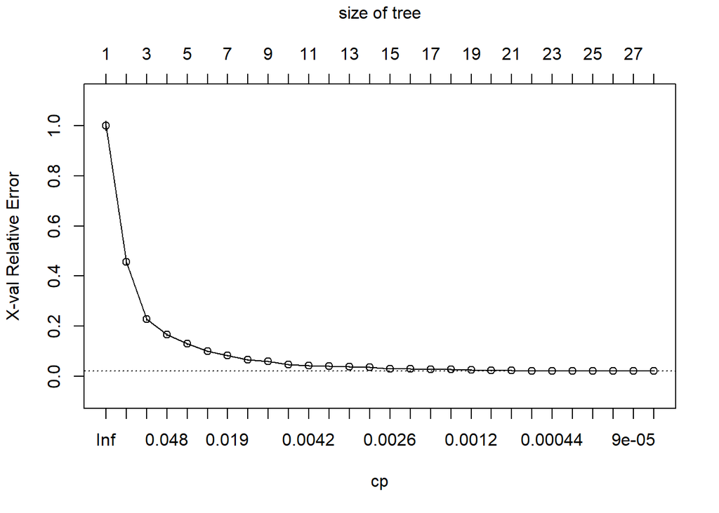

```r
plotcp(tree.model)
```

As mentioned earlier, in practice, **select the largest `cp` where `xerror` is within 1 standard error of the minimum (to balance simplicity and accuracy).**

To be more specific,

- Identify the minimum `xerror` and its `cp`.
- Get the standard error (`xstd`) of the minimum `xerror`.
- Find the simplest tree (`cp`) Where `xerror $\le$ Threshold`.
- Prune the tree using `best_cp` (best and simplest tree).

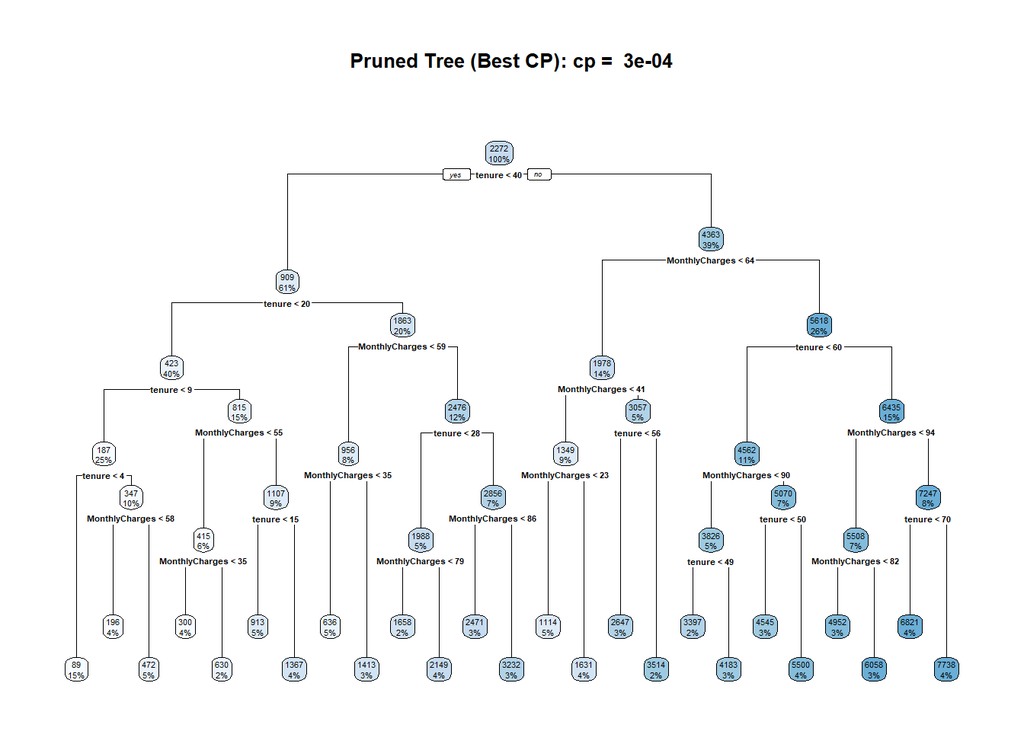

```r
cp.table <- tree.model$cptable

## Identify the minimum `xerror` and its `cp`.
min.xerror <- min(cp.table[, "xerror"])
min.cp.row <- which.min(cp.table[, "xerror"])
min.cp <- cp.table[min.cp.row, "CP"]

## Get the standard error (`xstd`) of the minimum `xerror`
xerror.std <- cp.table[min.cp.row, "xstd"]
threshold <- min.xerror + xerror.std  # Upper bound (1 SE rule)

## Find the simplest tree (`cp`) Where `xerror less than or equal to Threshold`.
best.cp.row <- which(cp.table[, "xerror"] <= threshold)[1]  # First row meeting criteria
best.cp <- cp.table[best.cp.row, "CP"]

## Two different trees: best CP vs minimum CP
pruned.tree.best.cp <- prune(tree.model, cp = best.cp)
pruned.tree.min.cp <- prune(tree.model, cp = min.cp)

# Visualize the pruned tree: best CP
rpart.plot(pruned.tree.best.cp, main = paste("Pruned Tree (Best CP): cp = ", round(best.cp,4)))
```

The above regression tree uses the best CP value based on the 1-SE. The regression tree below is the pruned tree for minimum cp (cp = 0)

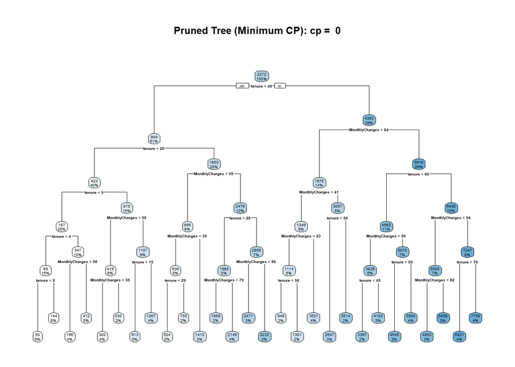

```r
# Visualize the pruned tree: minimum CP
rpart.plot(pruned.tree.min.cp, main = paste("Pruned Tree (Minimum CP): cp = ", round(min.cp,4)))
```

Next, we use the final pruned regression tree to make predictions. Since only two features tenure and MonthlyCharges were used in the algorithm. We also fit the step-wise-based linear regression model and compare the performance of the three models.

```r
# Linear regression model use all features through step-wise variable selection.

# 5. Prediction
# Make predictions on test data
pred.best.cp <- predict(pruned.tree.best.cp, newdata = test.data)
pred.min.cp <- predict(pruned.tree.min.cp, newdata = test.data)


# Evaluate model performance: best.cp
mse.tree.best.cp <- mean((test.data$TotalCharges - pred.best.cp)^2)
rmse.tree.best.cp <- sqrt(mse.tree.best.cp)
r.squared.tree.best.cp <- cor(test.data$TotalCharges, pred.best.cp)^2
# min.cp
mse.tree.min.cp <- mean((test.data$TotalCharges - pred.min.cp)^2)
rmse.tree.min.cp <- sqrt(mse.tree.min.cp)
r.squared.tree.min.cp <- cor(test.data$TotalCharges, pred.min.cp)^2

##
# fit ordinary least square regression
LSE <- lm(TotalCharges ~ tenure + MonthlyCharges, data = train.data)
AIC.fit <- stepAIC(LSE, direction="both", trace = FALSE)
pred.lse <-  predict(AIC.fit, newdata = test.data)
mse.lse <- mean((test.data$TotalCharges - pred.lse)^2) # mean square error
rmse.lse <- sqrt(mse.lse)                        # root mean square error
r.squared.lse <- cor(test.data$TotalCharges, pred.lse)^2   # r-squared

###
Errors <- cbind(MSE = c(mse.tree.best.cp, mse.tree.min.cp, mse.lse),
                RMSE = c(rmse.tree.best.cp, rmse.tree.min.cp, rmse.lse),
                r.squared = c(r.squared.tree.best.cp, r.squared.tree.min.cp, r.squared.lse))
rownames(Errors) = c("tree.best.cp", "tree.min.cp", "lse")
pander(Errors)
```

|  | MSE | RMSE | r.squared |
| --- | --- | --- | --- |
| **tree.best.cp** | 103477 | 321.7 | 0.9795 |
| **tree.min.cp** | 101042 | 317.9 | 0.98 |
| **lse** | 565232 | 751.8 | 0.8886 |

The pruned tree with CP corresponding best and minimum cross-validation error greatly outperformed the AIC step-wise linear regression model.

**Variable importance** in regression trees identifies which predictors have the strongest influence on the target variable’s predictions. In rpart, for each variable,

- Sum all improvements in squared error (RSS reduction) resulting from splits using that variable
- Scales the values so the most important variable gets 100
- All others are expressed relative to this maximum

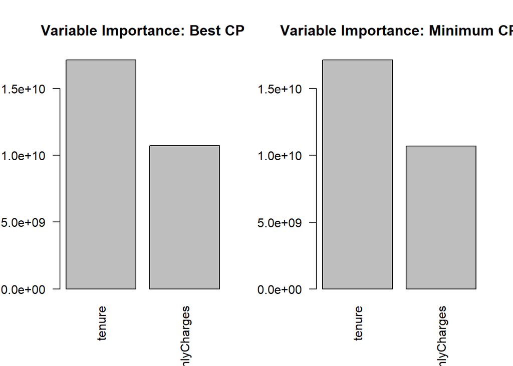

```r
par(mfrow = c(1,2))

# Variable importance
importance <- pruned.tree.best.cp$variable.importance
barplot(sort(importance, decreasing = TRUE),
        main = "Variable Importance: Best CP",
        las = 2)

# Variable importance
importance <- pruned.tree.min.cp$variable.importance
barplot(sort(importance, decreasing = TRUE),
        main = "Variable Importance: Minimum CP",
        las = 2)
```

For comparison, we also print out the inferential table of the step-wise linear regression model in the following.

```r
pander(summary(AIC.fit)$coef)
```

|  | Estimate | Std. Error | t value | Pr(>\|t\|) |
| --- | --- | --- | --- | --- |
| **(Intercept)** | -2161 | 26.1 | -82.81 | 0 |
| **tenure** | 66.33 | 0.4385 | 151.3 | 0 |
| **MonthlyCharges** | 35.5 | 0.3587 | 98.96 | 0 |

## 3.2 Bagging Regression

**Bootstrap Aggregation**, commonly known as **BAGGING**, is an ensemble learning technique designed to improve the stability and accuracy of machine learning algorithms, particularly those that exhibit high variance, such as decision trees. BAGGING operates on the principle of reducing variance by **averaging** (for regression) or **voting over** (for classification) multiple models trained on different bootstrap samples of the data set.

The follwing Bagging Regression processes involve generating multiple bootstrap samples from the training data, training individual regression trees on each subset, and aggregating their predictions—typically through averaging—to produce a more robust and stable regression model. This ensemble approach reduces variance and enhances generalization compared to a single regression tree.

### 3.2.1 Hyperparameter Tuning

In the CART examples from the previous note, four key hyperparameters - `cp` (complexity parameter), `maxdepth` (maximum tree depth), `minsplit` (minimum split size), and `minbucket` (minimum leaf size) - were tuned to regulate tree growth and prevent overfitting. For simplicity, this demonstration focuses on tuning only `cp` and `maxdepth`, while the remaining parameters retain their default values as specified below:

- `minsplit` = 20,
- `minbucket` = round(`minsplit`/3),
- `maxcompete` = 4,
- `maxsurrogate` = 5,
- `usesurrogate` = 2,
- `xval` = 10,
- `surrogatestyle` = 0,

The dataset is partitioned into 80% training and 20% testing subsets, with hyperparameter optimization conducted via **5-fold cross-validation** on the training partition to balance bias-variance trade-offs.

```r
# Load required packages
library(mlbench)
library(caret)
library(ipred)
#library(rpart)

# Load the Boston Housing dataset

data <- churn_lin

# Split the data
set.seed(123)
train.index <- createDataPartition(data$TotalCharges, p = 0.8, list = FALSE)
train.data <- data[train.index, ]
test.data <- data[-train.index, ]

# Set up train control for cross-validation
ctrl <- trainControl(
  method = "cv",
  number = 5,
  verboseIter = TRUE
)

# Define parameter combinations to test
nbagg.values <- c(10, 25, 50)     # number bagged trees
cp.values <- c(0.01, 0.05, 0.1)   # candidate cp values
maxdepth.values <- c(5, 10, 20)   # maximum depth of the candidate tree

# Create an empty data frame to store results
results <- data.frame()
######## Model tuning
# Manual tuning loop
for (nbagg in nbagg.values) {
  for (cp in cp.values) {
    for (maxdepth in maxdepth.values) {
      set.seed(123)
      model <- bagging(
        TotalCharges ~ .,
        data = train.data,
        nbagg = nbagg,
        coob = TRUE,
        trControl = ctrl,
        control = rpart.control(cp = cp,
                                maxdepth = maxdepth)
      )
      # Get OOB error from each iteration
      oob.error <- model$err
      # Store results
      results <- rbind(results,
                       data.frame( nbagg = nbagg,
                                   cp = cp,
                                   maxdepth = maxdepth,
                                   oob.error = oob.error))
    }
  }
}
# Find the best combination that yields the minimum out-of-bag's error
best.params <- results[which.min(results$oob.error), ]
pander(best.params)
```

|  | nbagg | cp | maxdepth | oob.error |
| --- | --- | --- | --- | --- |
| **10** | 25 | 0.01 | 5 | 512.8 |

The above table gives the values of the tuned hyperparameters.

### 3.2.2 Final Model Identification

We employ the bagging() function from the R package ipred to train the final bagging regression model. The model’s predictive performance is evaluated on the test set using standard error metrics, which are then compared against both the base regression tree and ordinary least squares (OLS) regression. The following table summarizes the bagging model’s out-of-sample performance.

```r
# Train the final model with the best parameters
final.model <- bagging(
  TotalCharges ~ .,
  data = train.data,
  nbagg = best.params$nbagg,
  coob = TRUE,
  trControl = ctrl,
  control = rpart.control(cp = best.params$cp,
                          maxdepth = best.params$maxdepth),

  importance = TRUE
)

# Evaluate on test set
predictions <- predict(final.model, newdata = test.data)
## Using the caret function to calculate errors across re-samples
baggedError <- postResample(pred = predictions, obs = test.data$TotalCharges)
pander(baggedError)
```

| RMSE | Rsquared | MAE |
| --- | --- | --- |
| 516.4 | 0.9493 | 413.6 |

### 3.2.3 Variable Importance

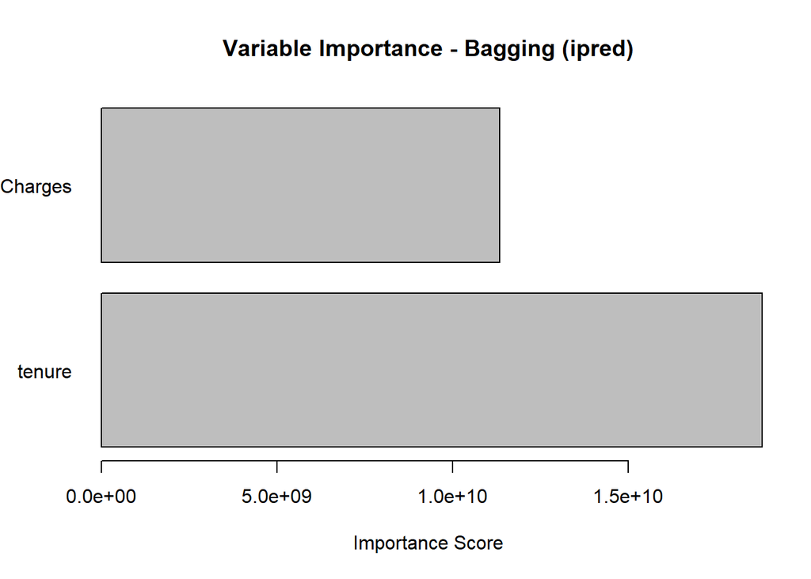

```r
##
var.imp <- varImp(final.model)
# Extract variable importance (requires a custom function)
get.bagging.importance <- function(model) {
  # Get all the trees from the bagging model
  trees <- model$mtrees

  # Initialize importance vector
  imp <- numeric(length(trees[[1]]$btree$variable.importance))
  names(imp) <- names(trees[[1]]$btree$variable.importance)

  # Sum importance across all trees
  for(tree in trees) {
    imp[names(tree$btree$variable.importance)] <-
      imp[names(tree$btree$variable.importance)] +
      tree$btree$variable.importance
  }

  # Average importance
  imp <- imp/length(trees)
  return(imp)
}

# Get importance
importance.scores <- get.bagging.importance(final.model)

# Sort and plot
importance.scores <- sort(importance.scores, decreasing = TRUE)
barplot(importance.scores, horiz = TRUE, las = 1,
        main = "Variable Importance - Bagging (ipred)",
        xlab = "Importance Score")
```

### 3.2.4 Performance Comparison

We now evaluate the performance of the bagged tree model against two benchmark models: (1) an optimized base regression tree (pruned using the complexity parameter cp that minimized cross-validation error) and (2) a standard Gaussian linear regression model. The following comparison assesses their predictive accuracy on the test set.

```r
##
## ordinary LSE regression model with step-wise variable selection
lse.fit <- lm(TotalCharges~.,data = train.data)
AIC.fit <- stepAIC(lse.fit, direction="both", trace = FALSE)
##
pred.lse <- predict(AIC.fit, test.data)
mae.lse <- mean(abs(test.data$TotalCharges - pred.lse)) # mean absolutesquare error
mse.lse <- mean((test.data$TotalCharges - pred.lse)^2)  # mean square error
rmse.lse <- sqrt(mse.lse)                       # root mean square error
r.squared.lse <- (cor(test.data$TotalCharges, pred.lse))^2 # r-squared
##
# Base regression tree
tree.model <- rpart(TotalCharges ~ .,
                    data = train.data,
                    method = "anova",     # For regression
                    control = rpart.control(
                      minsplit = 20,    # 3. Stopping rule: min observations to split
                      minbucket = 7,    # Min observations in terminal node
                      cp = seq(0, 0.05, 20), # Complexity parameter
                      maxdepth = 5      # Maximum tree depth
                    ))
# cp table
cp.table <- tree.model$cptable
##
## Identify the minimum `xerror` and its `cp`.
min.xerror <- min(cp.table[, "xerror"])
min.cp.row <- which.min(cp.table[, "xerror"])
min.cp <- cp.table[min.cp.row, "CP"]
##
pruned.tree.min.cp <- prune(tree.model, cp = min.cp)
pred.min.cp <- predict(pruned.tree.min.cp, newdata = test.data)
##
# min.cp
mae.tree.min.cp <- mean(abs(test.data$TotalCharges - pred.min.cp))
mse.tree.min.cp <- mean((test.data$TotalCharges - pred.min.cp)^2)
rmse.tree.min.cp <- sqrt(mse.tree.min.cp)
r.squared.tree.min.cp <- cor(test.data$TotalCharges, pred.min.cp)^2
##
###
Errors <- cbind(MAE = c(baggedError[1], mae.tree.min.cp, mae.lse),
                RMSE = c(baggedError[3], rmse.tree.min.cp, rmse.lse),
                r.squared = c(baggedError[2], r.squared.tree.min.cp, r.squared.lse))
rownames(Errors) = c("bagged Tree", "tree.min.cp", "lse")
pander(Errors)
```

[output not shown]

## 3.3 Random Forest Regression

Random Forest (RF) is an ensemble learning method that constructs multiple decision or regression trees during training and outputs the mode of the classes (for classification) or the mean prediction (for regression) of the individual trees.

Unlike a single regression/classification tree, which can overfit noisy data, a Random Forest introduces randomness in two key ways:

- **Bootstrap Sampling** (Random Sampling with Replacement): Each tree is trained on a different random subset of the training data (i.e., bootstrap data sets).
- **Feature Randomness**: At each split in a decision tree, only a **random subset of features** is considered, reducing correlation among trees and enhancing diversity.

The final prediction is obtained by averaging (for regression) or majority voting (for classification) the predictions of all individual trees, leading to a more stable and accurate model compared to a single decision tree. Random Forests are particularly effective in handling high-dimensional data, nonlinear relationships, and interactions between predictors without requiring extensive feature engineering.

**Random Forest Regression** combines multiple **regression trees** to produce a robust and accurate predictive model. It operates on the principle of bootstrap aggregation (bagging), where numerous regression trees are trained on **different bootstrap data sets** with **different subsets of randomly selected feature variables**, and their predictions are averaged to reduce variance and improve generalization.

The same modeling process of BAGGING regression applies to the **random forest** regression. It begins by splitting the dataset into training and testing sets to evaluate the model’s performance on unseen data. During training, each regression tree is built using a **bootstrap sample** and **random feature subsets**, with splits optimized to minimize Mean Squared Error (MSE), achieving reduced overfitting. **Hyperparameter tuning** - such as adjusting the number of trees, tree depth, and minimum samples per leaf - is performed using cross-validation to optimize model accuracy. The best configuration is then retrained on the full training set, with final predictions derived by averaging the outputs of all trees. Performance is assessed using metrics like MSE, RMSE, and $R^2$ to assess prediction accuracy and variance explanation.

### 3.3.1 Hyperparameter Tuning

Among many hyperparameters, the following are four key ones.

- **ntree**: Number of trees in the forest.
- **mtry**: Number of feature variables randomly sampled as candidates at each split. The default is $\sqrt{p}$, $p$ -s the number of feature variables in the data set. `mtry = p` induces BAGGING regression trees.
- **nodesize**: Minimum size of terminal nodes.
- **maxnodes**: Maximum number of terminal nodes.

Next, we will tune these hyperparameters through an explicit 5-fold cross-validation. From a coding perspective, we will define a data frame to store all possible combinations of hyperparameters and then use a single loop to complete the tuning step and report the **optimal** hyperparameters.

```r
library(randomForest)

# Create a grid (data frame) of hyperparameter combinations to test
hyper.grid <- expand.grid(
  ntree = c(100, 300, 500),
  mtry = c(3, 5, 7), # Dependent on the total number features available in the data
  nodesize = c(1, 3, 5),
  maxnodes = c(5, 10, 20, NULL)
)
##
# Initialize results storage
results <- data.frame()  # combination of hyperparameters and corresponding RMSE
best.rmse <- Inf         # place-holder of RMSE with initial value inf
best.params <- list()    # update the hyperparameter list according to the best rmse

# Set up k-fold cross-validation
k <- 5                   # 5-fold cross-validation
n0 <- dim(train.data)[1] # size of the training data
fold.size <- floor(n0/k) # fold size. Caution: floor() should be used.
# round( ,0) should be used. why?

# Loop through each hyperparameter combination
for(i in 1:nrow(hyper.grid)) {
  current.params <- hyper.grid[i, ]   # vector of hyperparameters for cross validation
  cv.errors <- numeric(k)             # store RMSE from cross-validation

  # Perform k-fold cross-validation
  for(j in 1:k) {
    # Split into training and validation folds
    valid.indices <- (1 + fold.size*(j-1)):(fold.size*j)  # CV observation ID vector
    cv.train <- train.data[-valid.indices, ]   # training data in cross-validation
    cv.valid <- train.data[valid.indices, ]    # testing data in cross-validation

    # Train model with current parameters
    rf.model <- randomForest(
      TotalCharges ~ .,
      data = cv.train,
      ntree = current.params$ntree,
      mtry = current.params$mtry,
      nodesize = current.params$nodesize,
      maxnodes = current.params$maxnodes,
      importance = TRUE
    )

    # Make predictions on validation set
    preds <- predict(rf.model, newdata = cv.valid)

    # Calculate RMSE
    cv.errors[j] <- sqrt(mean((preds - cv.valid$TotalCharges)^2))
  }

  # Average RMSE across folds
  avg.rmse <- mean(cv.errors)

  # Store results: the data frame defined to store combinations of hyperparameters
  # and the resulting mean RMSEs from cross-validation
  results <- rbind(results, data.frame(
    ntree = current.params$ntree,
    mtry = current.params$mtry,
    nodesize = current.params$nodesize,
    maxnodes = ifelse(is.null(current.params$maxnodes), "NULL", current.params$maxnodes),
    rmse = avg.rmse
  ))

  # Update best parameters if current model is better
  if(avg.rmse < best.rmse) {
    best.rmse <- avg.rmse
    best.params <- current.params
  }
  # Print progress: It is always a good idea to print something out in loops
  # cat(paste0("Completed ", i, "/", nrow(hyper.grid), " - RMSE: ", round(avg.rmse, 4), "\n"))
}
pander(data.frame(cbind(current.params,best.rmse)))    # resulting tuned hyperparameters
```

|  | ntree | mtry | nodesize | maxnodes | best.rmse |
| --- | --- | --- | --- | --- | --- |
| **81** | 500 | 7 | 5 | 20 | 325.4 |

### 3.3.2 Final Model Retaining and Evaluation

The final predictive mode needs to be retained using the training data and the tuned hyperparameters obtained in the above step.

[figure not shown]

```r
# Train final model with best parameters on full training set
final.rf <- randomForest(
  TotalCharges ~ .,
  data = train.data,
  ntree = best.params$ntree,
  mtry = best.params$mtry,
  nodesize = best.params$nodesize,
  maxnodes = best.params$maxnodes,
  importance = TRUE
)

# View model summary
# print(final.rf)
# Make predictions on test set
test.preds <- predict(final.rf, newdata = test.data)

# Calculate test RMAE
test.mae <- mean(abs(test.preds - test.data$TotalCharges))
# Calculate test RMSE
test.rmse <- sqrt(mean((test.preds - test.data$TotalCharges)^2))
# Calculate R-squared
test.r2 <- 1 - sum((test.data$TotalCharges - test.preds)^2) / sum((test.data$TotalCharges - mean(test.data$TotalCharges))^2)
# cat("Test R-squared:", test.r2, "\n")

### Performance vector
RF.performance = c(test.mae, test.rmse, test.r2)

# Plot actual vs predicted values
plot.data <- data.frame(Actual = test.data$TotalCharges, Predicted = test.preds)
ggplot(plot.data, aes(x = Actual, y = Predicted)) +
  geom_point() +
  geom_abline(intercept = 0, slope = 1, color = "red") +
  labs(title = "Actual vs Predicted Values",
       x = "Actual Median Value ($1000s)",
       y = "Predicted Median Value ($1000s)") +
  theme_minimal()
```

### 3.3.3 Performance Comparisons Among Competitors

Next, we compare the performance of random forest regression with least square linear regression, base regression tree, and BAGGING regression for predicting the TotalCharges value using the churn Data.

```r
## ordinary LSE regression model with step-wise variable selection
lse.fit <- lm(TotalCharges~.,data = train.data)
AIC.fit <- stepAIC(lse.fit, direction="both", trace = FALSE)
pred.lse <- predict(AIC.fit, test.data)
mae.lse <- mean(abs(test.data$TotalCharges - pred.lse))      # mean absolute error
mse.lse <- mean((test.data$TotalCharges - pred.lse)^2)       # mean square error
rmse.lse <- sqrt(mse.lse)                            # root mean square error
r.squared.lse <- (cor(test.data$TotalCharges, pred.lse))^2 # r-squared

### base regression tree
tree.model <- rpart(TotalCharges ~ .,
                    data = train.data,
                    method = "anova",     # For regression
                    control = rpart.control(
                      minsplit = 20,    # 3. Stopping rule: min observations to split
                      minbucket = 7,    # Min observations in terminal node
                      cp = seq(0, 0.05, 20), # Complexity parameter
                      maxdepth = 5      # Maximum tree depth
                    ))
cp.table <- tree.model$cptable
min.xerror <- min(cp.table[, "xerror"])
min.cp.row <- which.min(cp.table[, "xerror"])
min.cp <- cp.table[min.cp.row, "CP"]
##
pruned.tree.min.cp <- prune(tree.model, cp = min.cp)
pred.min.cp <- predict(pruned.tree.min.cp, newdata = test.data)
# performance measures
mae.tree.min.cp <- mean(abs(test.data$TotalCharges - pred.min.cp))   # MAD
mse.tree.min.cp <- mean((test.data$TotalCharges - pred.min.cp)^2)
rmse.tree.min.cp <- sqrt(mse.tree.min.cp)                    # MSE
r.squared.tree.min.cp <- cor(test.data$TotalCharges, pred.min.cp)^2  # R.sq

### bagging regression: from the previous section
BaggPerf <- baggedError

### Performance Comparison Table
Errors <- cbind(MAE = c(mae.lse, mae.tree.min.cp, BaggPerf[3], RF.performance[1]),
                RMSE = c(rmse.lse, rmse.tree.min.cp, BaggPerf[1], RF.performance[2]),
                r.squared = c(r.squared.lse, r.squared.tree.min.cp, BaggPerf[2],RF.performance[3]))
rownames(Errors) = c("LS Regression", "Regression Tree", "BAGGING", "Random Forest")
pander(Errors)
```

|  | MAE | RMSE | r.squared |
| --- | --- | --- | --- |
| **LS Regression** | 583.7 | 733.2 | 0.8971 |
| **Regression Tree** | 210.1 | 301 | 0.9827 |
| **BAGGING** | 413.6 | 516.4 | 0.9493 |
| **Random Forest** | 239.4 | 352.6 | 0.9762 |

The performance table above demonstrates that all tree-based regression models consistently outperform the least squares linear regression model. Among the tree-based algorithms, random forest regression performs slightly worse than the single regression tree, but much better than the bagging regression. Although all tree-based regression models could not be “smart” enough to detect the perfect linear relationship of TotalCharges with the interaction of tenure and MonthlyCharges, they performs way much better than the the least squares linear regression model in the absence of manually generated feature variable Prd_TotalCharges - the interaction of tenure and MonthlyCharges.

### 3.3.4 Variable Importance

The following variable importance plots are based on the MSE and node impurity.

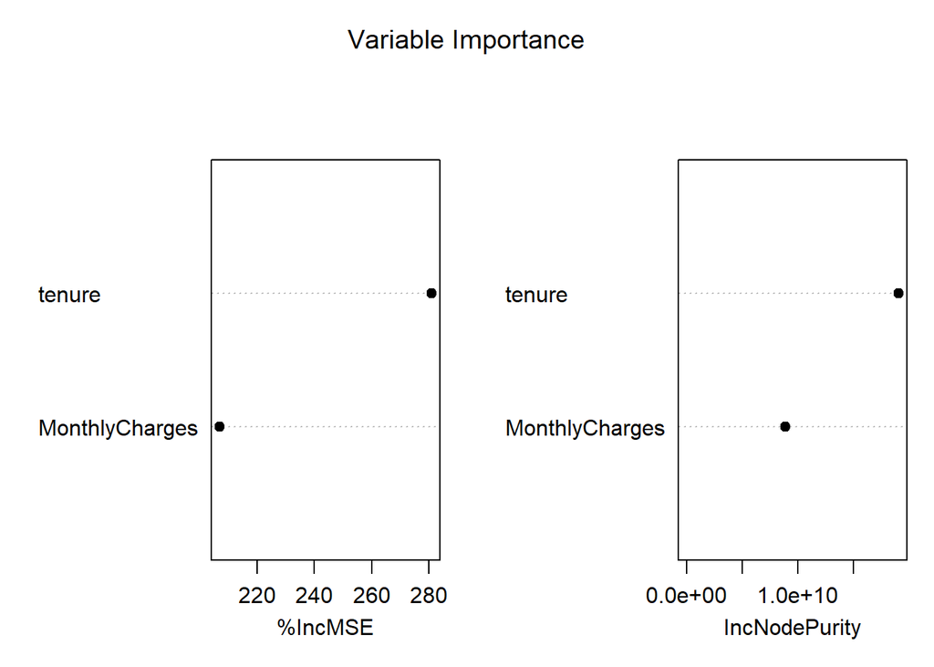

```r
# View variable importance
varImpPlot(final.rf, pch = 19, main = "Variable Importance")
```

# 4 Part II: Predict churn with CART Classification, Bagging Classification and Random Forest Classification

Here we use 3 numerical variables (tenure, MonthlyCharges and TotalCharges) and other converted dummy variables To predict the probability of churn with CART Classification, Bagging Classification and Random Forest Classification models.

## 4.1 CART Classification

CART Classification trees are a type of supervised learning algorithm that recursively partitions the feature space to predict categorical target variables. The algorithm follows a greedy top-down approach (also called recursive partitioning) to build a decision tree.

The logical process of implementing a classification algorithm is similar to that of regression trees. Here we outline these basic steps.

- **Tree Induction** - The process of building the tree by recursively partitioning the data:
  - Start with the entire dataset at the root node
  - Recursively split the data into purer subsets
  - Continue until stopping criteria are met
- **Splitting Criteria (Feature Selection and Splitting)** - Determining how to split nodes:
  - For categorical targets: Typically use Gini impurity or information gain (entropy)
  - For each possible split, calculate the improvement in purity
  - Select the split that provides maximum improvement
  - **Optimal Tree Size**: Typically where `xerror` is minimized.
- **Stopping Rule** - Conditions to terminate tree growth:
  - Minimum number of observations in a node
  - Maximum tree depth
  - Minimum improvement in purity required for a split
  - All observations in a node belong to one class
- **Pruning Process** - Reducing tree size to prevent overfitting:
  - Grow the tree to a maximum depth
  - Use cost-complexity pruning to remove less important branches
  - Select optimal tree size using cross-validation
- **Prediction**
  - Using the final tree to make predictions:
  - Traverse the tree with new observations
  - Assign the majority class of the terminal node
  - Can output class probabilities

Since CART algorithms allow too many hyperparameters, tuning hyperparameters can be challenging. Here are what we do based on recommendations:

- **Start with Defaults**: `minsplit=20`, `minbucket=7`, `cp=0.01`.
- **Adjust Based on Data Size**
  - For small datasets, reduce `minsplit` and `minbucket`.
  - For large datasets, increase `maxdepth`.
- **Use Pruning (cp) to avoid overfitting**
  - Higher `cp` leads to a simpler tree.
  - Lower `cp` leads to more complex tree (risk of overfitting).
- Cross-validation (`xval=10`) to select the best `cp`.
- **Optimal Tree Size**: Typically where `xerror` is minimized.

We will use the **Telco Customer Churn dataset** to illustrate the process of building a classification tree model and will compare its predictive performance with that of logistic regression through ROC analysis.

The data set contains 7043 customers’ data, with the target variable churn indicating whether the customer may terminate Telco’s contract.

### 4.1.1 Grown An Initial Tree

The initial tree size is controlled by some default hyperparameters `rpart.control()`. It tends to be over-fitted.

In classification, one particularly challenging problem is that the classes (categories) are not equally represented. This is a common issue in real-world applications, such as fraud detection, medical diagnosis, and spam filtering, where one class (the minority class) is significantly underrepresented compared to the other(s) (the majority class). To improve the predictive performance of the classification tree algorithm with the imbalanced categorical response, `rpart()` allows to inclusion of a loss matrix to penalize the misclassification (false positives and false negatives).

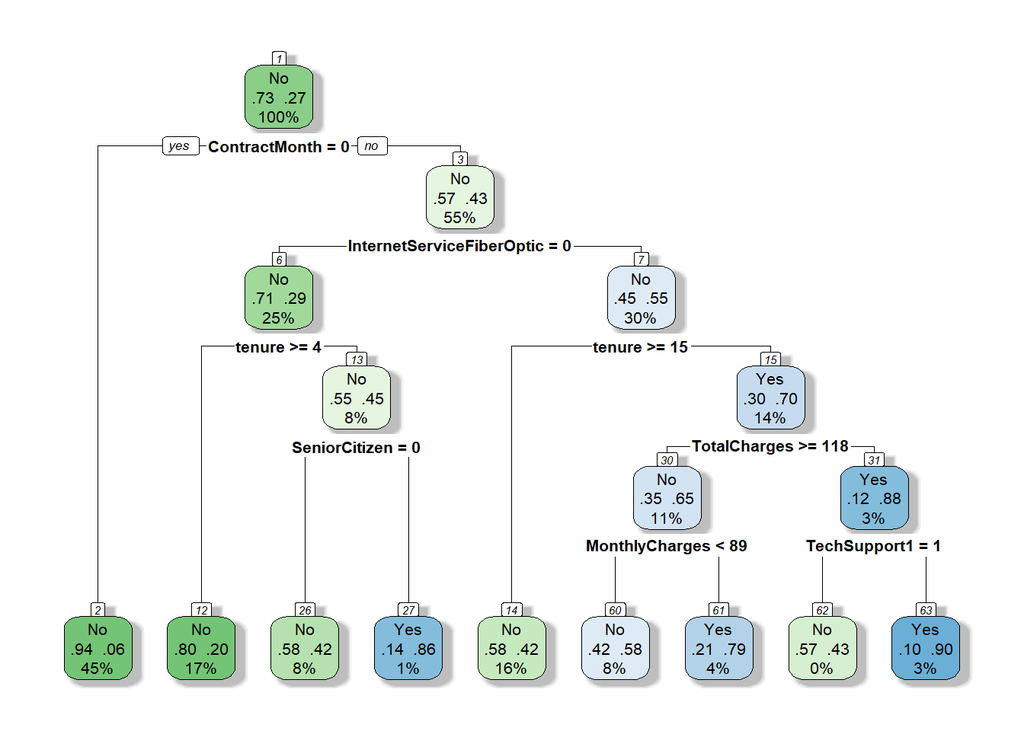

```r
# Load necessary libraries
# library(rpart)        # For decision trees
# library(rpart.plot)   # For visualizing trees
# library(caret)        # For model evaluation
library(pROC)         # For ROC analysis

# Load the dataset
churn2 <- churn2[, c("tenure", "MonthlyCharges", "TotalCharges", "Partner1", "Dependents1", "PhoneService1", "MultipleLines1", "InternetService1", "OnlineSecurity1", "SeniorCitizen",
                    "OnlineBackup1", "DeviceProtection1", "TechSupport1",
                    "StreamingTV1", "StreamingMovies1", "PaperlessBilling1",  "InternetServiceNo", "InternetServiceFiberOptic",
                    "InternetServiceDSL", "ContractMonth",
                    "Contract1Year", "Contract2Year", "PaymentMethodECheck",
                    "PaymentMethodMCheck", "PaymentMethodCreditCard", "PaymentMethodBankTranfer",
                    "gender1", "Churn"     )]

# Split data into training (70%) and test (30%) sets
set.seed(123)
train.index <- createDataPartition(churn2$Churn, p = 0.7, list = FALSE)
train.data <- churn2[train.index, ]
test.data <- churn2[-train.index, ]

# Build the initial classification tree
tree.model <- rpart(Churn ~ .,
                    data = train.data,
                    method = "class",   # classification tree
                    parms = list(split = "gini",  # Using Gini index
                                 # FN cost = 1, FP cost = 0.5
                                 loss = matrix(c(0, 0.5, 1, 0), nrow = 2)
                    ),
                    control = rpart.control(minsplit = 15,  # Min 15 obs to split
                                            minbucket = 5,   # Min 7 obs in leaf
                                            # Complexity parameter
                                            cp = 0.001, # complex parameter
                                            maxdepth = 5))   # Max tree depth

rpart.plot(tree.model,
           extra = 104, # check the help document for more information
           # color palette is a sequential color scheme that blends green (G) to blue (Bu)
           box.palette = "GnBu",
           branch.lty = 1,
           shadow.col = "gray",
           nn = TRUE)
```

The above tree diagram represents the initial settings in parameters and hyperparameters in arguments parms= and rpart.control.

### 4.1.2 Pruning Tree

To prevent overfitting in decision trees, we employ both pre-pruning and post-pruning strategies. Pre-pruning is implemented through hyperparameters in rpart.control and parms within the rpart() function, which restrict tree growth during construction. Post-pruning, performed after tree development, uses cross-validation to select an optimal complexity parameter (cp), with two recommended approaches: (1) choosing the cp value that minimizes cross-validation error (xerror), or (2) applying the 1-SE rule - selecting the largest cp where xerror ≤ (min xerror + 1 standard error) to balance model complexity and predictive performance.

The following cp table below is used to identify the value of cp to build the final tree.

```r
# Print the complexity parameter table
pander(tree.model$cptable)
```

| CP | nsplit | rel error | xerror | xstd |
| --- | --- | --- | --- | --- |
| 0.01553 | 0 | 1 | 2 | 0.04738 |
| 0.007639 | 5 | 0.8785 | 1.683 | 0.04425 |
| 0.00382 | 7 | 0.8633 | 1.66 | 0.04399 |
| 0.001 | 8 | 0.8594 | 1.645 | 0.04385 |

The following cp-plot gives the reference line (broken line) for 1-SE rule. The numbers on the top of the plot represent the leaf nodes in the final tree diagram.

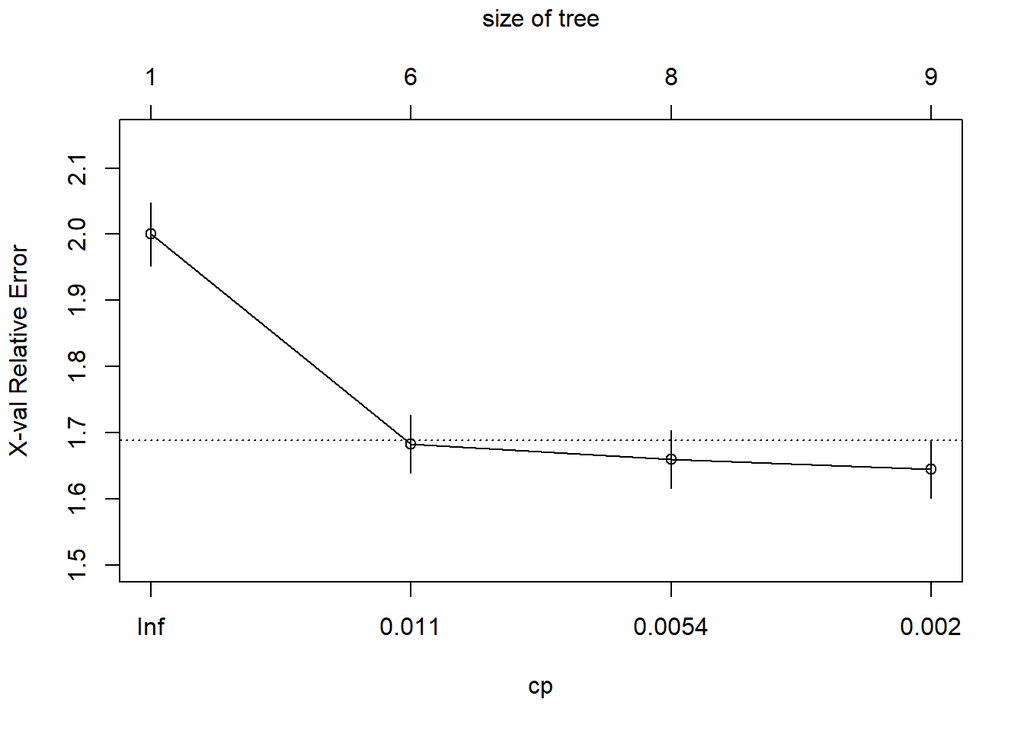

```r
# Plot the cross-validation results
plotcp(tree.model)
```

For clarity in the analysis, we introduce two notations: min.cp represents the cp value yielding the minimum cross-validation error, while 1SE.cp denotes the cp value selected by the more conservative 1-SE rule (minimal error plus one standard error).Here based on the cp table we generated above (minimu xerror 1.645 + 1 standard error 0.04385), we use the cp = 0.008 to predict the optimal tree model.

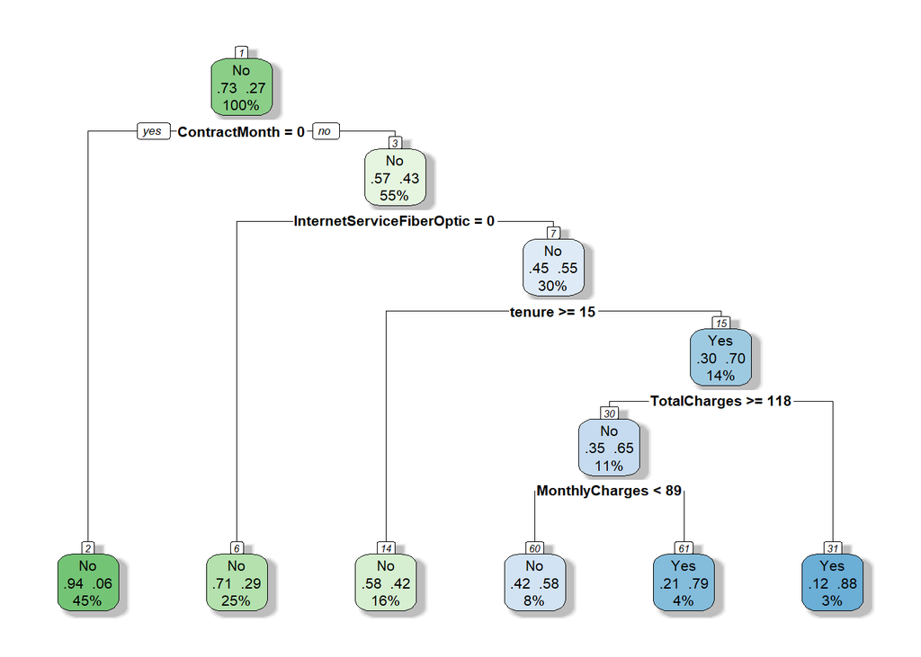

```r
# Find the optimal cp value that minimizes cross-validated error
min.cp <- tree.model$cptable[which.min(tree.model$cptable[,"xerror"]),"CP"]

# Prune the tree using the optimal cp
pruned.tree.1SE <- prune(tree.model, cp = 0.008)
pruned.tree.min <- prune(tree.model, cp = min.cp)

# Visualize the pruned tree
rpart.plot(pruned.tree.1SE,
           extra = 104, # check the help document for more information
           # color palette is a sequential color scheme that blends green (G) to blue (Bu)
           box.palette = "GnBu",
           branch.lty = 1,
           shadow.col = "gray",
           nn = TRUE)
```

The above-pruned tree diagram is based on the 1-SE rule. Next, we plot the tree diagram based on the minimum cross-validation error.

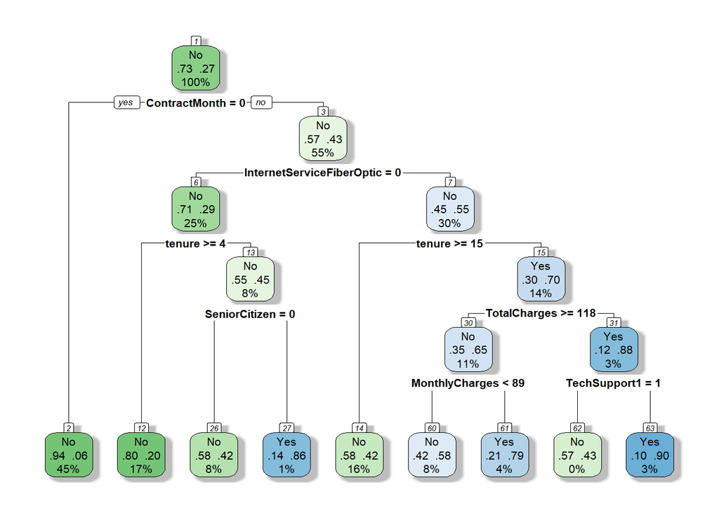

```r
# Visualize the pruned tree
rpart.plot(pruned.tree.min,
           extra = 104, # check the help document for more information
           # color palette is a sequential color scheme that blends green (G) to blue (Bu)
           box.palette = "GnBu",
           branch.lty = 1,
           shadow.col = "gray",
           nn = TRUE)
```

### 4.1.3 Global Performance with ROC

Classification trees make predictions by routing observations through a series of hierarchical splits, starting at the root node and ending at a terminal leaf node. Each split applies a decision rule based on feature values. In R, predictions can be generated as class labels (type = “class”) or probabilities (type = “prob”), offering flexibility for different use cases—such as hard classifications for decision-making or probabilities for risk scoring.

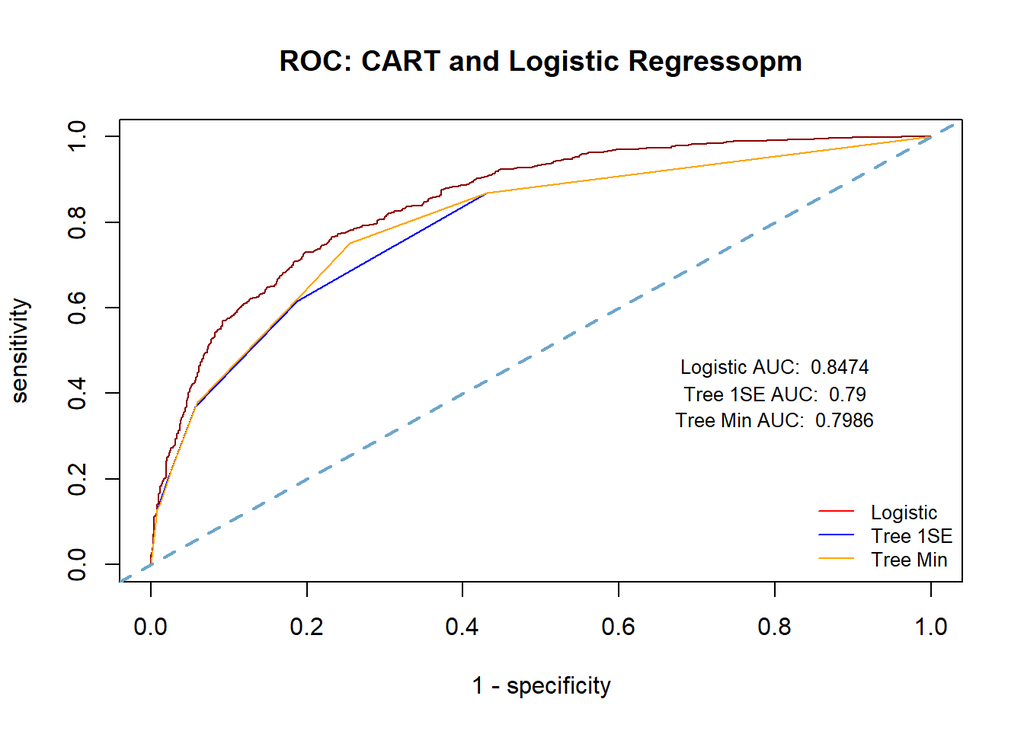

```r
# Make predictions on the test set
pred.label.1SE <- predict(pruned.tree.1SE, test.data, type = "class") # default cutoff 0.5
pred.prob.1SE <- predict(pruned.tree.1SE, test.data, type = "prob")[,2]
##
pred.label.min <- predict(pruned.tree.min, test.data, type = "class") # default cutoff 0.5
pred.prob.min <- predict(pruned.tree.min, test.data, type = "prob")[,2]

# Confusion matrix
#conf.matrix <- confusionMatrix(pred.label, test.data$Churn, positive = "Yes")
#print(conf.matrix)

########################
###  logistic regression
train.data$Churn <- as.factor(train.data$Churn)

# Set the positive class (if needed)
train.data$Churn <- relevel(train.data$Churn, ref = "Yes")  # or "No"

# Fit the model
logit.fit <- glm(Churn ~ ., data = train.data, family = binomial)
AIC.logit <- step(logit.fit, direction = "both", trace = 0)
pred.logit <- predict(AIC.logit, test.data, type = "response")

# ROC curve and AUC
roc.tree.1SE <- roc(test.data$Churn, pred.prob.1SE)
roc.tree.min <- roc(test.data$Churn, pred.prob.min)
roc.logit <- roc(test.data$Churn, pred.logit)

##
### Sen-Spe
tree.1SE.sen <- roc.tree.1SE$sensitivities
tree.1SE.spe <- roc.tree.1SE$specificities
#
tree.min.sen <- roc.tree.min$sensitivities
tree.min.spe <- roc.tree.min$specificities
#
logit.sen <- roc.logit$sensitivities
logit.spe <- roc.logit$specificities
## AUC
auc.tree.1SE <- roc.tree.1SE$auc
auc.tree.min <- roc.tree.min$auc
auc.logit <- roc.logit$auc
###
plot(1-logit.spe, logit.sen,
     xlab = "1 - specificity",
     ylab = "sensitivity",
     col = "darkred",
     type = "l",
     lty = 1,
     lwd = 1,
     main = "ROC: CART and Logistic Regressopm")
lines(1-tree.1SE.spe, tree.1SE.sen,
      col = "blue",
      lty = 1,
      lwd = 1)
lines(1-tree.min.spe, tree.min.sen,
      col = "orange",
      lty = 1,
      lwd = 1)
abline(0,1, col = "skyblue3", lty = 2, lwd = 2)
legend("bottomright", c("Logistic", "Tree 1SE", "Tree Min"),
       lty = c(1,1,1), lwd = rep(1,3),
       col = c("red", "blue", "orange"),
       bty="n",cex = 0.8)
## annotation - AUC
text(0.8, 0.46, paste("Logistic AUC: ", round(auc.logit,4)), cex = 0.8)
text(0.8, 0.4, paste("Tree 1SE AUC: ", round(auc.tree.1SE,4)), cex = 0.8)
text(0.8, 0.34, paste("Tree Min AUC: ", round(auc.tree.min,4)), cex = 0.8)
```

The ROC curves and corresponding AUC values demonstrate that the logistic regression model achieves much better performance compared to both pruned tree models, with the more complex tree (pruned using minimum cross-validation error) showing slightly better predictive ability than the simpler tree pruned according to the 1-SE rule.

### 4.1.4 Optimal Cut-off Probability

In binary classification, predicted probabilities must be converted into class labels (e.g., 0 or 1) by applying a cut-off threshold. The choice of this threshold significantly impacts model performance, as it balances accuracy, sensitivity (recall), and specificity. Depending on the particular application, below are key approaches to determine the optimal cut-off.

**I. Trade-off Between Sensitivity and Specificity**

Sensitivity (True Positive Rate) measures how well a test identifies true positives, such as correctly detecting diseases, while specificity (True Negative Rate) assesses its ability to correctly rule out negatives, like avoiding false alarms. These metrics often trade off against each other, so choosing the optimal threshold depends on the costs of false positives versus false negatives. A common approach to balancing these metrics is maximizing Youden’s J statistic, which optimizes the trade-off between sensitivity and specificity.

$$J = \text{Sensitivity} + \text{Specificity} - 1$$

The threshold that maximizes J balances both metrics.

**II. Accuracy-Driven Cut-off**

Accuracy is maximized when the threshold matches the class distribution, with a default of 0.5 for balanced data, but a higher threshold may improve accuracy in imbalanced datasets (e.g., 90% negatives) by reducing false positives. However, accuracy can be misleading in imbalanced scenarios (e.g., 99% accuracy from always predicting the majority class), making alternatives like the geometric mean (G-Mean) a better metric for evaluating model performance.

$$G = \text{Sensitivity} \times \text{Specificity}$$

This penalizes thresholds that sacrifice one metric for the other.

**III. Cost-Sensitive Thresholding**

When misclassification costs are known (e.g., FN costs 10× more than FP), the threshold can be optimized to minimize total cost:

**IV. ROC and Precision-Recall Curves**

The **ROC curve** plots the **True Positive Rate (TPR)** against the **False Positive Rate (FPR)**, helping to identify the optimal threshold by targeting the top-left corner for the best balance between sensitivity and specificity. In contrast, the **Precision-Recall** curve is more suitable for imbalanced data sets, focusing on the trade-off between precision and recall, with thresholds often selected to maximize metrics like the **F1-score**. Each curve serves a distinct purpose depending on the data distribution and classification goals.

**V. An Illustrative Example**

However, since **FPR = 1 - Specificity** and **FNR = 1 - Sensitivity**, it is not straightforward to directly use the information from the pROC object. To address this, we calculate the number of **false negatives (FN)** and **false positives (FP)** at each cut-off point. Then, assuming—for illustrative purposes—that the cost of a **false positive (FP)** is 5 and the cost of a **false negative (FN)** is 20, we evaluate a cost function to determine the optimal probability threshold. This cost-based approach helps identify the cut-off that minimizes overall misclassification costs.

$$\text{cost} = 5\times FP + 20 \times FN.$$

We consider the pruned tree `tree.min` in the following. *Note the cut-off probability is identified using the training data.*

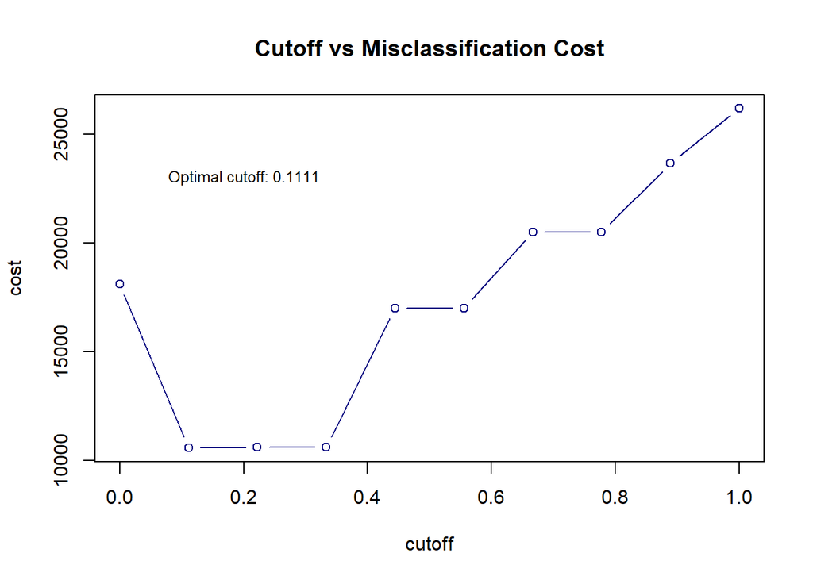

```r
# preditive probabilities of tree.min model.
pred.prob.min <- predict(pruned.tree.min, train.data, type = "prob")[,2]
##
cost <- NULL
cutoff <-seq(0,1, length = 10)
##
for (i in 1:10){
  pred.label <- ifelse(pred.prob.min > cutoff[i], "Yes", "No")
  FN <- sum(pred.label == "No" & train.data$Churn == "Yes")
  FP <- sum(pred.label == "Yes" & train.data$Churn == "No")
  cost[i] = 5*FP + 20*FN
}
## identify optimal cut-off
min.ID <- which(cost == min(cost))   # could have multiple minimum
optim.prob <- mean(cutoff[min.ID])   # take the average of the cut-offs
##
plot(cutoff, cost, type = "b", col = "navy",
     main = "Cutoff vs Misclassification Cost")
##
text(0.2, 23000, paste("Optimal cutoff:", round(optim.prob,4)), cex = 0.8)
```

## 4.2 Bagging Classifcation

### 4.2.1 Hyperparameter Tuning**

The hyperparameters to be tuned in BAGGING classification algorithms are

- **nbagg**: Number of bootstrap samples (trees)
- **control**: Parameters for the base learner (rpart in this case)
- **minsplit**: Minimum number of observations in a node before splitting
- **maxdepth**: Maximum depth of the tree
- **cp**: Complexity parameter

We will use `expand.grid` in base R to create a data frame from all combinations of the supplied vectors or factors so that we tune multiple hyperparameters in a single loop.

```r
# Load necessary libraries
# library(caret)     # For machine learning functions
# library(ipred)     # For bagging implementation
# library(rpart)     # For decision trees (default base learner)
# library(mlbench)   # Contains churn2 dataset

# Load the dataset
#churn2 <- churn2[1:1000,]
#
# Set seed for reproducibility
set.seed(123)

# Split data into training and testing sets
trainIndex <- createDataPartition(churn2$Churn, p = 0.7, list = FALSE)
trainData <- churn2[trainIndex, ]
testData <- churn2[-trainIndex, ]

trainData$Churn <- as.factor(trainData$Churn)

# Set the positive class (if needed)
trainData$Churn <- relevel(trainData$Churn, ref = "Yes")  # or "No"

testData$Churn <- as.factor(testData$Churn)

# Set the positive class (if needed)
testData$Churn <- relevel(testData$Churn, ref = "Yes")  # or "No"

# Create a grid of hyperparameter combinations
hyper.grid <- expand.grid(
  nbagg = c(25, 50, 100),
  minsplit = c(5, 10, 20),
  maxdepth = c(5, 10, 20),
  cp = c(0.01, 0.001)
)
# Initialize a results data frame
results <- data.frame() # store values of tuned hyperparameters
best.accuracy <- 0      # store accuracy
best.params <- list()   # store best values of hyperparameter

# Loop through each hyperparameter combination
for(i in 1:nrow(hyper.grid)) {
  # Get current hyperparameters
  params <- hyper.grid[i, ]

  # Set rpart control parameters
  rpart.control <- rpart.control(
    minsplit = params$minsplit,
    maxdepth = params$maxdepth,
    cp = params$cp
  )

  # Train bagging model
  bag.model <- bagging(
    Churn ~ .,
    data = trainData,
    nbagg = params$nbagg,
    coob = TRUE,
    control = rpart.control
  )

  # Make predictions: default cut-off 0.5
  preds <- predict(bag.model, newdata = testData)

  # Calculate accuracy
  cm <- confusionMatrix(preds, testData$Churn)
  accuracy <- cm$overall["Accuracy"]

  # Store results
  results <- rbind(results, data.frame(
    nbagg = params$nbagg,
    minsplit = params$minsplit,
    maxdepth = params$maxdepth,
    cp = params$cp,
    Accuracy = accuracy
  ))

  # Update best parameters if current model is better
  if(accuracy > best.accuracy) {
    best.accuracy <- accuracy
    best.params <- params
  }

  # Print progress
  #cat("Completed", i, "of", nrow(hyper.grid), "combinations\n")
}
pander(best.params) # run 20min
```

|  | nbagg | minsplit | maxdepth | cp |
| --- | --- | --- | --- | --- |
| **14** | 50 | 10 | 10 | 0.01 |

The above-tuned values of hyperparameters will be used to fit the final BAGGING classification model.

### 4.2.2 Train Final Model With Best Hyperparameters

```r
# Set rpart control with best parameters
best.control <- rpart.control(
  minsplit = best.params$minsplit,
  maxdepth = best.params$maxdepth,
  cp = best.params$cp
)

# Train final model
final.bag.model <- bagging(
  Churn ~ .,
  data = trainData,
  nbagg = best.params$nbagg,
  coob = TRUE,
  control = best.control
)

# Evaluate on test set
final.preds <- predict(final.bag.model, newdata = testData)
final.cm <- confusionMatrix(final.preds, testData$Churn)
final.cm$table
```

```
          Reference
Prediction  Yes   No
       Yes  267  141
       No   293 1411
```

We use BAGGING classification tree to the test data to predict churn status with the default cut-off probability. Then we have the above confusion matrix. With the confusion matrix, we can calculate variable performance measures.

### 4.2.3 Global Measures and Comparisons

We will compare the BAGGING classification model with the base classification tree as well as the logistic regression model using ROC analysis and the area under the corresponding curves.

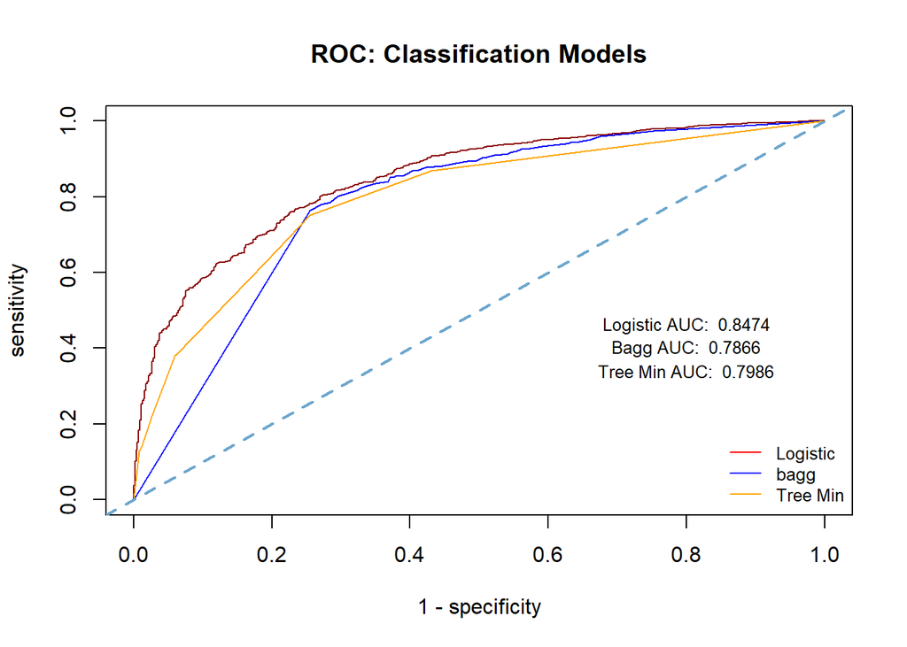

```r
########################
###  logistic regression
logit.fit <- glm(Churn ~ ., data = trainData, family = binomial)
AIC.logit <- step(logit.fit, direction = "both", trace = 0)
pred.logit <- predict(AIC.logit, testData, type = "response")
##
# Build the initial classification tree
# tree.model <- rpart(Churn ~ .,
#                     data = trainData,
#                    method = "class",   # classification tree
#                     parms = list(split = "gini",  # Using Gini index
#                                  # FN cost = 1, FP cost = 0.5
#                                  loss = matrix(c(0, 0.5, 1, 0), nrow = 2)
#                     ),
#                     control = rpart.control(minsplit = 15,  # Min 15 obs to split
#                                             minbucket = 5,   # Min 7 obs in leaf
#                                             # Complexity parameter
#                                             cp = 0.001, # complex parameter
#                                             maxdepth = 5))   # Max tree depth
###
# min.cp <- tree.model$cptable[which.min(tree.model$cptable[,"xerror"]),"CP"]

# Prediction with three candidate models
# pruned.tree.min <- prune(tree.model, cp = min.cp)
# pred.label.min <- predict(pruned.tree.min, testData, type = "class") # default cutoff 0.5
# pred.prob.min <- predict(pruned.tree.min, testData, type = "prob")[,2]
pred.prob.bagg <- predict(final.bag.model, newdata = testData, type = "prob")[,2]
##
# ROC object
# roc.tree.min <- roc(testData$Churn, pred.prob.min)
roc.logit <- roc(testData$Churn, pred.logit)
roc.bagg <- roc(testData$Churn, pred.prob.bagg)
##
##
### Sen-Spe
bagg.sen <- roc.bagg$sensitivities
bagg.spe <- roc.bagg$specificities
#
# tree.min.sen <- roc.tree.min$sensitivities
# tree.min.spe <- roc.tree.min$specificities
#
logit.sen <- roc.logit$sensitivities
logit.spe <- roc.logit$specificities
## AUC
auc.bagg <- roc.bagg$auc
# auc.tree.min <- roc.tree.min$auc
auc.logit <- roc.logit$auc
###
plot(1-logit.spe, logit.sen,
     xlab = "1 - specificity",
     ylab = "sensitivity",
     col = "darkred",
     type = "l",
     lty = 1,
     lwd = 1,
     main = "ROC: Classification Models")
lines(1-bagg.spe, bagg.sen,
      col = "blue",
      lty = 1,
      lwd = 1)
lines(1-tree.min.spe, tree.min.sen,
      col = "orange",
      lty = 1,
      lwd = 1)
abline(0,1, col = "skyblue3", lty = 2, lwd = 2)
legend("bottomright", c("Logistic", "bagg", "Tree Min"),
       lty = c(1,1,1), lwd = rep(1,3),
       col = c("red", "blue", "orange"),
       bty="n",cex = 0.8)
## annotation - AUC
text(0.8, 0.46, paste("Logistic AUC: ", round(auc.logit,4)), cex = 0.8)
text(0.8, 0.4, paste("Bagg AUC: ", round(auc.bagg,4)), cex = 0.8)
text(0.8, 0.34, paste("Tree Min AUC: ", round(auc.tree.min,4)), cex = 0.8)
```

In terms of model performance ranking, the logistic regression model is the best. BAGGING performs slightly worse than the base tree model.

## 4.3 Random Forest Classification

Implementing a random forest classification model begins with splitting the dataset into training and testing sets. Once the data is prepared, an initial random forest model is trained using default hyperparameters, such as the number of decision trees, maximum tree depth, and minimum samples required to split a node. The out-of-bag (OOB) error or cross-validation metrics like accuracy, precision, recall, and F1-score are used to assess the baseline performance. Feature importance analysis can also be conducted to identify the most influential predictors in the model.

In this subsection, we will manually tune a Random Forest model using custom loops in R, evaluating different hyperparameter combinations on the Telco customer data set. Hyperparameter tuning is then performed to optimize model performance using techniques like grid search. Key hyperparameters will be tuned through 5-fold cross-validation is used to stabilize the AUCs and ensure to identification of the best hyperparameters the final random forest model is retrained on the full training set. The model’s performance is evaluated on the test set using metrics like accuracy, ROC-AUC, and a confusion matrix to assess classification effectiveness.

### 4.3.1 Multiple Hyperparameter Tuning

We perform hyperparameter tuning through 5-fold cross-validation. As mentioned earlier, the key hyperparameters in random forest models are

- **mtry**: Number of variables randomly sampled as candidates at each split
- **ntree**: Number of trees to grow
- **nodesize**: Minimum size of terminal nodes
- **maxnodes**: Maximum number of terminal nodes trees can have

The performance metric used in the 5-fold cross-validation is the area under the ROC curve (AUC). For each combination of candidate hyperparameters, the model’s performance will be evaluated based on the average AUC across all folds.

```r
# library(randomForest)
# library(caret)
# library(pROC)

data <- na.omit(churn2)

set.seed(123)
train.idx <- createDataPartition(data$Churn, p = 0.7, list = FALSE)
train.data <- data[train.idx, ]
test.data <- data[-train.idx, ]

train.data$Churn <- as.factor(train.data$Churn)
# Set the positive class (if needed)
train.data$Churn <- relevel(train.data$Churn, ref = "Yes")  # or "No"

test.data$Churn <- as.factor(test.data$Churn)

# Set the positive class (if needed)
test.data$Churn <- relevel(test.data$Churn, ref = "Yes")  # or "No"

# cross-validation setting
k = 5
train.size <- dim(train.data)[1]  # training data size
fold.size <- floor(train.size/k)  # fold size

##
tune.grid <- expand.grid(
  mtry = c(2, 3, 4, 5),
  ntree = c(100, 300, 500),
  nodesize = c(1, 3, 5, 10),
  maxnodes = c(5, 10, 20, NULL)
)
### store hyperparameters and avg of cv AUC
results <- data.frame()
best.auc <- 0.5         # place-holder of AUC, 0.5 = random guess
best.hyp.params <- list()   # update the hyperparameter list according to the best auc

##
for (i in 1:nrow(tune.grid)){
  current.tune.params <- tune.grid[i, ]  # subset of DATA FRAME!!
  cv.auc <- rep(0,k)
  ##
  for (j in 1:k){
    cv.id <- (1 + (j-1)*fold.size):(j*fold.size)
    cv.train <- train.data[-cv.id, ]
    cv.valid <- train.data[cv.id, ]
    ##
    rf.cv <- randomForest(
      Churn ~ .,
      data = cv.train,
      mtry = current.tune.params$mtry,
      ntree = current.tune.params$ntree,
      nodesize = current.tune.params$nodesize,
      maxnodes = current.tune.params$maxnodes)
    ##
    prob.cv <- predict(rf.cv, cv.valid, type = "prob")[, "Yes"]
    cv.auc[j] <- auc(roc(cv.valid$Churn, prob.cv))
  }
  ##
  # Average RMSE across folds
  avg.auc <- mean(cv.auc)
  ##
  # Store results: the data frame defined to store combinations of hyperparameters
  # and the resulting mean RMSEs from cross-validation
  results <- rbind(results, data.frame(
    mtry = current.tune.params$mtry,
    ntree = current.tune.params$ntree,
    nodesize = current.tune.params$nodesize,
    maxnodes = current.tune.params$maxnodes,
    auc = avg.auc))

  # Update best parameters if current model is better
  if(avg.auc > best.auc) {
    best.auc <- avg.auc
    best.hyp.params <- current.tune.params }

}
pander(data.frame(cbind(best.hyp.params,best.auc)))    # resulting tuned hyperparameters
```

|  | mtry | ntree | nodesize | maxnodes | best.auc |
| --- | --- | --- | --- | --- | --- |
| **117** | 2 | 500 | 3 | 20 | 0.8393 |

### 4.3.2 Final Model Training and Evaluation

With the above-tuned hyperparameters, we train the following random forest model. The confusion matrix’s statistics, performance, and the AUC of test data is shown below.

```r
##
final.rf.cls <- randomForest(
  Churn ~ .,
  data = train.data,
  ntree = best.hyp.params$ntree,
  mtry = best.hyp.params$mtry,
  nodesize = best.hyp.params$nodesize,
  maxnodes = current.tune.params$maxnodes,
  importance = TRUE
)

test.pred <- predict(final.rf.cls, test.data)
test.prob <- predict(final.rf.cls, test.data, type = "prob")
rf.roc <- roc(test.data$Churn, test.prob[, "Yes"])
test.auc <- auc(rf.roc)
confusionMatrix(test.pred, test.data$Churn)
```

```
Confusion Matrix and Statistics

          Reference
Prediction  Yes   No
       Yes  170   54
       No   390 1498

               Accuracy : 0.7898
                 95% CI : (0.7718, 0.807)
    No Information Rate : 0.7348
    P-Value [Acc > NIR] : 2.764e-09

                  Kappa : 0.3325

 Mcnemar's Test P-Value : < 2.2e-16

            Sensitivity : 0.30357
            Specificity : 0.96521
         Pos Pred Value : 0.75893
         Neg Pred Value : 0.79343
             Prevalence : 0.26515
         Detection Rate : 0.08049
   Detection Prevalence : 0.10606
      Balanced Accuracy : 0.63439

       'Positive' Class : Yes
```

```r
test.auc
```

```
Area under the curve: 0.8411
```

The variable importance is reflected in the two plots below.

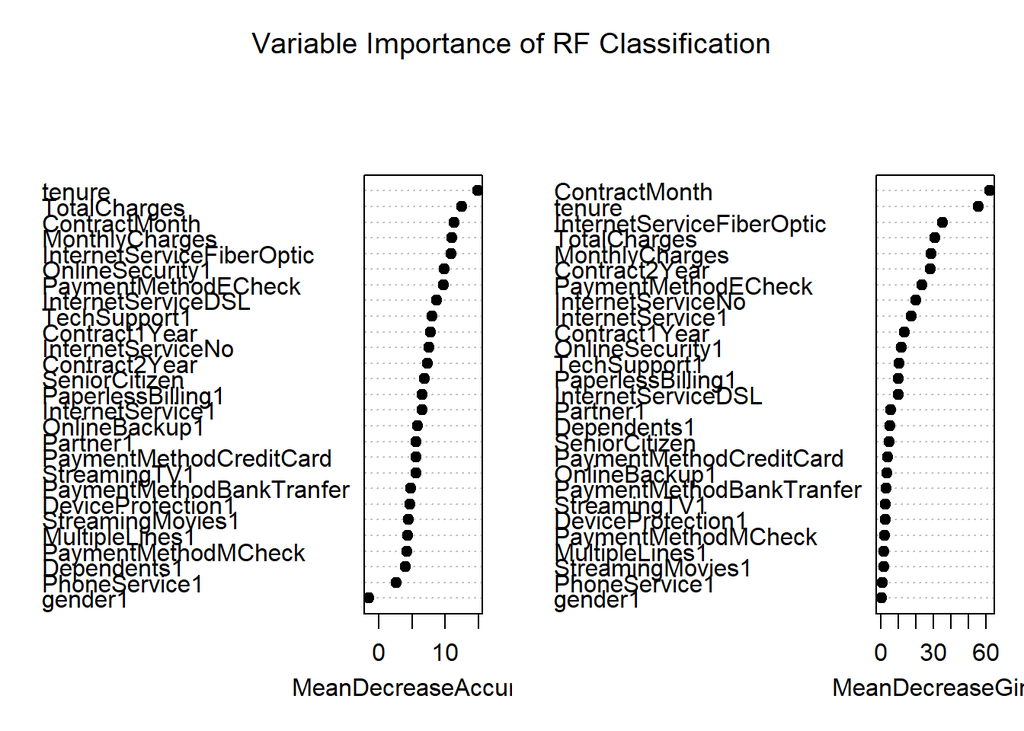

```r
# Variable Importance
varImpPlot(final.rf.cls, pch = 19, main = "Variable Importance of RF Classification" )
```

### 4.3.3 Comparison to Competitors

We now compare the random forest classification model with competitors including BAGGING, classification tree, and logistic regression models using global performance metric AUC.

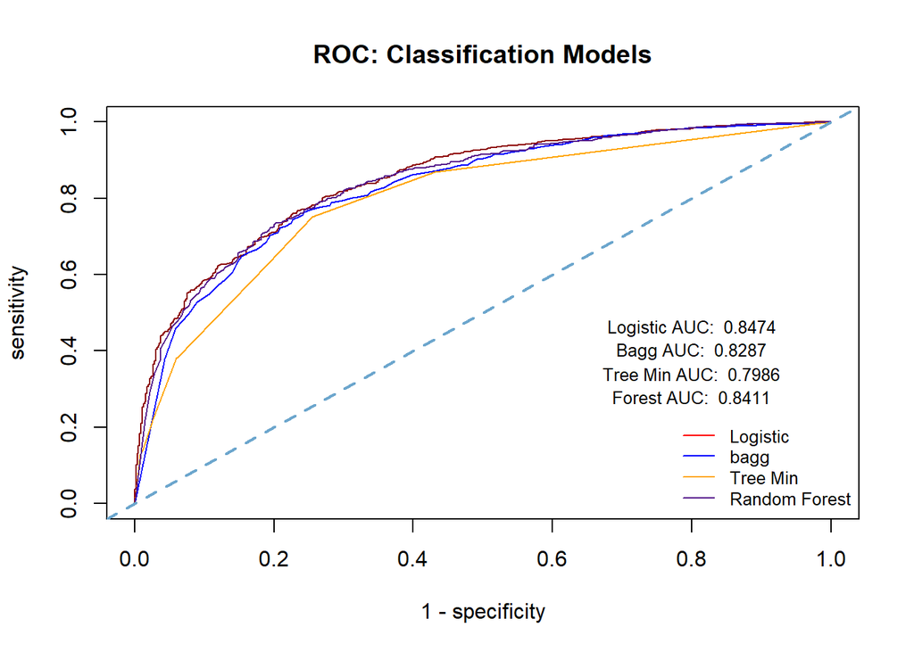

```r
########################
###  logistic regression
logit.fit <- glm(Churn ~ ., data = train.data, family = binomial)
AIC.logit <- step(logit.fit, direction = "both", trace = 0)
pred.logit <- predict(AIC.logit, test.data, type = "response")

# Build the initial classification tree
# tree.model <- rpart(Churn ~ .,
#                     data = train.data,
#                     method = "class",   # classification tree
#                     parms = list(split = "gini",  # Using Gini index
#                                  # FN cost = 1, FP cost = 0.5
#                                  loss = matrix(c(0, 0.5, 1, 0), nrow = 2)
#                     ),
#                     control = rpart.control(minsplit = 15,  # Min 15 obs to split
#                                             minbucket = 5,   # Min 7 obs in leaf
#                                             # Complexity parameter
#                                             cp = 0.001, # complex parameter
#                                             maxdepth = 5))   # Max tree depth
# Find the optimal cp value that minimizes cross-validated error
# min.cp <- tree.model$cptable[which.min(tree.model$cptable[,"xerror"]),"CP"]
# pruned.tree.min <- prune(tree.model, cp = min.cp)


# BAGGING
# Create a grid of hyperparameter combinations
hyper.grid <- expand.grid(
  nbagg = c(25, 50, 100),
  minsplit = c(5, 10, 20),
  maxdepth = c(5, 10, 20),
  cp = c(0.01, 0.001)
)
# Initialize a results dataframe
results <- data.frame() # store values of tuned hyperparameters
best.accuracy <- 0      # store accuracy
best.params <- list()   # store best values of hyperparameter

# Loop through each hyperparameter combination
for(i in 1:nrow(hyper.grid)) {
  # Get current hyperparameters
  params <- hyper.grid[i, ]

  # Set rpart control parameters
  rpart.control <- rpart.control(
    minsplit = params$minsplit,
    maxdepth = params$maxdepth,
    cp = params$cp
  )

  # Train bagging model
  bag.model <- bagging(
    Churn ~ .,
    data = train.data,
    nbagg = params$nbagg,
    coob = TRUE,
    control = rpart.control
  )

  # Make predictions: default cut-off 0.5
  preds <- predict(bag.model, newdata = test.data)

  # Calculate accuracy
  cm <- confusionMatrix(preds, test.data$Churn)
  accuracy <- cm$overall["Accuracy"]

  # Store results
  results <- rbind(results, data.frame(
    nbagg = params$nbagg,
    minsplit = params$minsplit,
    maxdepth = params$maxdepth,
    cp = params$cp,
    Accuracy = accuracy
  ))

  # Update best parameters if current model is better
  if(accuracy > best.accuracy) {
    best.accuracy <- accuracy
    best.params <- params
  }
}
# Set rpart control with best parameters
best.control <- rpart.control(
  minsplit = best.params$minsplit,
  maxdepth = best.params$maxdepth,
  cp = best.params$cp
)

# Train final model
final.bag.model <- bagging(
  Churn ~ .,
  data = train.data,
  nbagg = best.params$nbagg,
  coob = TRUE,
  control = best.control
)
#pred.prob.bagg <- predict(final.bag.model, newdata = test.data, type = "prob")[,2]
###
# Prediction with three candidate models
# pruned.tree.min <- prune(tree.model, cp = min.cp)
# pred.label.min <- predict(pruned.tree.min, test.data, type = "class") # default cutoff 0.5
# pred.prob.min <- predict(pruned.tree.min, test.data, type = "prob")[,2]
pred.prob.bagg <- predict(final.bag.model, newdata = test.data, type = "prob")[,2]
##
# ROC object
# roc.tree.min <- roc(test.data$Churn, pred.prob.min)
roc.logit <- roc(test.data$Churn, pred.logit)
roc.bagg <- roc(test.data$Churn, pred.prob.bagg)
roc.rf <- roc(test.data$Churn, test.prob[, "Yes"])

##
##
### Sen-Spe
bagg.sen <- roc.bagg$sensitivities
bagg.spe <- roc.bagg$specificities
#
# tree.min.sen <- roc.tree.min$sensitivities
# tree.min.spe <- roc.tree.min$specificities
#
logit.sen <- roc.logit$sensitivities
logit.spe <- roc.logit$specificities
#
rf.sen <- roc.rf$sensitivities
rf.spe <- roc.rf$specificities

## AUC
auc.bagg <- roc.bagg$auc
# auc.tree.min <- roc.tree.min$auc
auc.logit <- roc.logit$auc
auc.rf <- roc.rf$auc
###
###
plot(1-logit.spe, logit.sen,
     xlab = "1 - specificity",
     ylab = "sensitivity",
     col = "darkred",
     type = "l",
     lty = 1,
     lwd = 1,
     main = "ROC: Classification Models")
lines(1-bagg.spe, bagg.sen,
      col = "blue",
      lty = 1,
      lwd = 1)
lines(1-tree.min.spe, tree.min.sen,
      col = "orange",
      lty = 1,
      lwd = 1)
lines(1-rf.spe, rf.sen,
      col = "purple4",
      lty = 1,
      lwd = 1)
abline(0,1, col = "skyblue3", lty = 2, lwd = 2)
legend("bottomright", c("Logistic", "bagg", "Tree Min", "Random Forest"),
       lty = c(1,1,1), lwd = rep(1,3),
       col = c("red", "blue", "orange", "purple4"),
       bty="n",cex = 0.8)
## annotation - AUC
text(0.8, 0.46, paste("Logistic AUC: ", round(auc.logit,4)), cex = 0.8)
text(0.8, 0.4, paste("Bagg AUC: ", round(auc.bagg,4)), cex = 0.8)
text(0.8, 0.34, paste("Tree Min AUC: ", round(auc.tree.min,4)), cex = 0.8)
text(0.8, 0.28, paste("Forest AUC: ", round(auc.rf,4)), cex = 0.8)
```

We can see from the above ROC analysis that the logistic regression model has better predictive power than tree-based classification models. Among tree-based classification models, random forest are have better predictive power than BAGGING, and both are better than the single classification tree model.